# Diss cleaning

SCL

2026-08-05

```r
library(pwr)      # pwr.f2.test
library(sjstats)  # design_effect
library(dplyr)
library(tibble)
library(purrr)
library(tidyverse)
library(janitor)
library(here)
library(psych)
library(car)
library(effectsize)
library(broom)
library(knitr)
library(kableExtra)
library(lattice)
library(nlme)
library(lubridate)
library(lme4)
library(lmerTest)
```

LOAD DATA

```r
library(here)
data_path = here::here("Diss_full.csv")
diss.full =  read.csv(data_path)
```

LET’S START CLEANING

```r
#make all the columns lowercase to help with coding
names(diss.full) = tolower(names(diss.full))
names(diss.full) =  iconv(names(diss.full), from = "", to = "UTF-8", sub = "")
names(diss.full) =  gsub("consent.*", "consent", names(diss.full))
```

Okay data is loaded. Now, we will clean it by the guidelines of the pre-reg.

Participants will be excluded if they: 1) do not consent or 2) complete the study in less than seven minutes or 3) exhibit no variability in their responses (e.g., selecting all 5s or all 3s) across all Integrity and likeability items, and 4) fail to complete the Integrity and likeability ratings for at least one vignettes.

An attention check will be used to assess whether participants paid attention during the experiment by requiring participants to select a specific response to the question (i.e., “Select the option “somewhat disagree” if you are paying attention.”). We will do an exploratory analysis to determine test if excluding those who fail the attention impacts the data.

```r
# Initial data count
initial_count =  nrow(diss.full)
print(initial_count)
```

```
## [1] 675
```

```r
# Clean recordeddate
diss.full$recordeddate =  str_squish(as.character(diss.full$recordeddate))
diss.full$created_date = mdy_hm(diss.full$recordeddate)

# Filters by cutoff date
cutoff_date =  as.Date("2026-01-27")
filtered_by_date = diss.full %>%
  filter(!is.na(created_date) & created_date >= cutoff_date)

count_by_date =  nrow(filtered_by_date)
print(count_by_date)
```

```
## [1] 675
```

```r
# Filter by consent
filtered_by_consent = filtered_by_date %>%
  filter(consent == "Yes, I consent")

count_by_consent =  nrow(filtered_by_consent)

# Filter by duration (exclude under 420 seconds)
filtered_by_duration = filtered_by_consent %>%
  filter(!is.na(duration..in.seconds.) & duration..in.seconds. >= 420)

count_by_duration = nrow(filtered_by_duration)

# Exclude participants under 18
filtered_by_age = filtered_by_duration %>%
  filter(is.na(age) | age >= 18)

count_by_age = nrow(filtered_by_age)


# Exclude no-variability: participants who gave identical responses across
# all Integrity and likeability items — uses apply() to avoid rowwise() issues
Integrity_like_cols = c("khon","ksin","keth","klike","kapp",
                    "shon","ssin","seth","slike","sapp",
                    "hhon","hsin","heth","hlike","happ",
                    "fhon","fsin","feth","flike","fapp",
                    "xhon","xsin","xeth","xlike","xapp",
                    "yhon","ysin","yeth","ylike","yapp")

tl_matrix = filtered_by_age %>%
  select(all_of(Integrity_like_cols)) %>%
  mutate(across(everything(), as.numeric))
has_variability = apply(tl_matrix, 1, function(row) n_distinct(na.omit(row)) > 1)
filtered_by_variability = filtered_by_age[has_variability, ]
count_by_variability = nrow(filtered_by_variability)

# Exclude attention check failures (attention1 == 2 is correct response)
filtered_by_attention = filtered_by_variability %>%
  filter(attention1 == 2)
count_by_attention = nrow(filtered_by_attention)
# Final count
final_count = nrow(filtered_by_age)

# Summary table
count_summary = data.frame(
  Step = c(
    "Initial",
    "After Date Filter",
    "After Consent Filter",
    "After Duration Filter",
    "After Age Filter",
    "Final"
  ),
  Count = c(
    initial_count,
    count_by_date,
    count_by_consent,
    count_by_duration,
    count_by_age,
    final_count
  )
)

print(count_summary)
```

```
##                    Step Count
## 1               Initial   675
## 2     After Date Filter   675
## 3  After Consent Filter   675
## 4 After Duration Filter   455
## 5      After Age Filter   455
## 6                 Final   455
```

```r
# Print counts
cat("Total rows in diss.full:", initial_count, "\n")
```

```
## Total rows in diss.full: 675
```

```r
cat("Rows after filtering by date:", count_by_date, "\n")
```

```
## Rows after filtering by date: 675
```

```r
cat("Rows after filtering by consent:", count_by_consent, "\n")
```

```
## Rows after filtering by consent: 675
```

```r
cat("Rows after filtering by duration:", count_by_duration, "\n")
```

```
## Rows after filtering by duration: 455
```

```r
cat("Rows after excluding participants under 18:", count_by_age, "\n")
```

```
## Rows after excluding participants under 18: 455
```

```r
cat("Final rows:", final_count, "\n")
```

```
## Final rows: 455
```

okay now we filter by ege

```r
attr_dat = filtered_by_age %>%
  select(
    responseid,
    minsmart, minbetter, mincreative, minrather, minshould, minregard, mintyp, minkeep, minget,
    modsmart, modbett, modcreat, modrath, modshou, modreg, modtyp, modkeep, modget,
    majsmart, majbet, majcreat, majrath, majshould, majreg, majtyp, majkeep, majget
  )
```

we need to pivot the data to be useable

```r
attr_long = attr_dat %>%
  pivot_longer(
    cols = -responseid,
    names_to = "raw_item",
    values_to = "choice_raw"
  )
```

Data has been pivoted so now we need to clean up some columns and make a column for severity.

```r
attr_long = attr_long %>%
  mutate(
    severity = case_when(
      str_detect(raw_item, "^min") ~ "minor",
      str_detect(raw_item, "^mod") ~ "moderate",
      str_detect(raw_item, "^maj") ~ "major",
      TRUE ~ NA_character_
    ),
    item_stub = str_remove(raw_item, "^(min|mod|maj)"),
    attribute = case_when(
      item_stub %in% c("smart") ~ "smarter",
      item_stub %in% c("better", "bett") ~ "better_researcher",
      item_stub %in% c("creative", "creat") ~ "creative",
      item_stub %in% c("rather", "rath") ~ "rather_be",
      item_stub %in% c("should", "shou") ~ "should_be",
      item_stub %in% c("regard", "reg") ~ "celebrated",
      item_stub %in% c("typ") ~ "typical",
      item_stub %in% c("keep") ~ "job_security",
      item_stub %in% c("get") ~ "job_outcome",
      TRUE ~ NA_character_
    )
  )
```

Check to make sure it looks correct and get a count

```r
head(attr_long, 20)
```

```
## # A tibble: 20 × 6
##    responseid        raw_item    choice_raw         severity item_stub attribute
##    <chr>             <chr>       <chr>              <chr>    <chr>     <chr>
##  1 R_1kWnphloUO7A7Tj minsmart    neither reported … minor    smart     smarter
##  2 R_1kWnphloUO7A7Tj minbetter   reporting researc… minor    better    better_r…
##  3 R_1kWnphloUO7A7Tj mincreative reporting researc… minor    creative  creative
##  4 R_1kWnphloUO7A7Tj minrather   reporting researc… minor    rather    rather_be
##  5 R_1kWnphloUO7A7Tj minshould   reporting researc… minor    should    should_be
##  6 R_1kWnphloUO7A7Tj minregard   reporting researc… minor    regard    celebrat…
##  7 R_1kWnphloUO7A7Tj mintyp      neither reported … minor    typ       typical
##  8 R_1kWnphloUO7A7Tj minkeep     reporting researc… minor    keep      job_secu…
##  9 R_1kWnphloUO7A7Tj minget      reporting researc… minor    get       job_outc…
## 10 R_1kWnphloUO7A7Tj modsmart    reporting researc… moderate smart     smarter
## 11 R_1kWnphloUO7A7Tj modbett     reporting researc… moderate bett      better_r…
## 12 R_1kWnphloUO7A7Tj modcreat    neither reported … moderate creat     creative
## 13 R_1kWnphloUO7A7Tj modrath     reporting researc… moderate rath      rather_be
## 14 R_1kWnphloUO7A7Tj modshou     reporting researc… moderate shou      should_be
## 15 R_1kWnphloUO7A7Tj modreg      reporting researc… moderate reg       celebrat…
## 16 R_1kWnphloUO7A7Tj modtyp      neither reported … moderate typ       typical
## 17 R_1kWnphloUO7A7Tj modkeep     reporting researc… moderate keep      job_secu…
## 18 R_1kWnphloUO7A7Tj modget      reporting researc… moderate get       job_outc…
## 19 R_1kWnphloUO7A7Tj majsmart    neither reported … major    smart     smarter
## 20 R_1kWnphloUO7A7Tj majbet      reporting researc… major    bet       <NA>
```

```r
table(attr_long$severity, useNA = "ifany")
```

```
##
##    major    minor moderate
##     4095     4095     4095
```

```r
table(attr_long$attribute, useNA = "ifany")
```

```
##
## better_researcher        celebrated          creative       job_outcome
##               910              1365              1365              1365
##      job_security         rather_be         should_be           smarter
##              1365              1365              1365              1365
##           typical              <NA>
##              1365               455
```

Okay i am working towards making a column that tells us researcher role now…

```r
attr_long2 = attr_long %>%
  tidyr::crossing(researcher = c("investigator", "inspector"))
```

figure out how many rows for the data

```r
head(attr_long2, 20)
```

```
## # A tibble: 20 × 7
##    responseid        raw_item choice_raw severity item_stub attribute researcher
##    <chr>             <chr>    <chr>      <chr>    <chr>     <chr>     <chr>
##  1 R_100RpLnF3upbBKT majbet   reporting… major    bet       <NA>      inspector
##  2 R_100RpLnF3upbBKT majbet   reporting… major    bet       <NA>      investiga…
##  3 R_100RpLnF3upbBKT majcreat neither r… major    creat     creative  inspector
##  4 R_100RpLnF3upbBKT majcreat neither r… major    creat     creative  investiga…
##  5 R_100RpLnF3upbBKT majget   reporting… major    get       job_outc… inspector
##  6 R_100RpLnF3upbBKT majget   reporting… major    get       job_outc… investiga…
##  7 R_100RpLnF3upbBKT majkeep  reporting… major    keep      job_secu… inspector
##  8 R_100RpLnF3upbBKT majkeep  reporting… major    keep      job_secu… investiga…
##  9 R_100RpLnF3upbBKT majrath  reporting… major    rath      rather_be inspector
## 10 R_100RpLnF3upbBKT majrath  reporting… major    rath      rather_be investiga…
## 11 R_100RpLnF3upbBKT majreg   reporting… major    reg       celebrat… inspector
## 12 R_100RpLnF3upbBKT majreg   reporting… major    reg       celebrat… investiga…
## 13 R_100RpLnF3upbBKT majshou… reporting… major    should    should_be inspector
## 14 R_100RpLnF3upbBKT majshou… reporting… major    should    should_be investiga…
## 15 R_100RpLnF3upbBKT majsmart reporting… major    smart     smarter   inspector
## 16 R_100RpLnF3upbBKT majsmart reporting… major    smart     smarter   investiga…
## 17 R_100RpLnF3upbBKT majtyp   reported … major    typ       typical   inspector
## 18 R_100RpLnF3upbBKT majtyp   reported … major    typ       typical   investiga…
## 19 R_100RpLnF3upbBKT minbett… neither r… minor    better    better_r… inspector
## 20 R_100RpLnF3upbBKT minbett… neither r… minor    better    better_r… investiga…
```

```r
dim(attr_long)
```

```
## [1] 12285     6
```

```r
dim(attr_long2)
```

```
## [1] 24570     7
```

assign values to researcher roles

```r
attr_long2 = attr_long2 %>%
  mutate(
    chosen = case_when(
      str_detect(choice_raw, "^reported researcher") & researcher == "investigator" ~ 1,
      str_detect(choice_raw, "^reporting researcher") & researcher == "inspector" ~ 1,
      str_detect(choice_raw, "^neither") ~ 0,
      TRUE ~ 0
    )
  )
```

Check to make sure it looks correct and get a count

```r
head(attr_long2, 20)
```

```
## # A tibble: 20 × 8
##    responseid raw_item choice_raw severity item_stub attribute researcher chosen
##    <chr>      <chr>    <chr>      <chr>    <chr>     <chr>     <chr>       <dbl>
##  1 R_100RpLn… majbet   reporting… major    bet       <NA>      inspector       1
##  2 R_100RpLn… majbet   reporting… major    bet       <NA>      investiga…      0
##  3 R_100RpLn… majcreat neither r… major    creat     creative  inspector       0
##  4 R_100RpLn… majcreat neither r… major    creat     creative  investiga…      0
##  5 R_100RpLn… majget   reporting… major    get       job_outc… inspector       1
##  6 R_100RpLn… majget   reporting… major    get       job_outc… investiga…      0
##  7 R_100RpLn… majkeep  reporting… major    keep      job_secu… inspector       1
##  8 R_100RpLn… majkeep  reporting… major    keep      job_secu… investiga…      0
##  9 R_100RpLn… majrath  reporting… major    rath      rather_be inspector       1
## 10 R_100RpLn… majrath  reporting… major    rath      rather_be investiga…      0
## 11 R_100RpLn… majreg   reporting… major    reg       celebrat… inspector       1
## 12 R_100RpLn… majreg   reporting… major    reg       celebrat… investiga…      0
## 13 R_100RpLn… majshou… reporting… major    should    should_be inspector       1
## 14 R_100RpLn… majshou… reporting… major    should    should_be investiga…      0
## 15 R_100RpLn… majsmart reporting… major    smart     smarter   inspector       1
## 16 R_100RpLn… majsmart reporting… major    smart     smarter   investiga…      0
## 17 R_100RpLn… majtyp   reported … major    typ       typical   inspector       0
## 18 R_100RpLn… majtyp   reported … major    typ       typical   investiga…      1
## 19 R_100RpLn… minbett… neither r… minor    better    better_r… inspector       0
## 20 R_100RpLn… minbett… neither r… minor    better    better_r… investiga…      0
```

```r
table(attr_long2$chosen, useNA = "ifany")
```

```
##
##     0     1
## 15303  9267
```

```r
table(attr_long2$researcher, attr_long2$chosen)
```

```
##
##                    0     1
##   inspector     4731  7554
##   investigator 10572  1713
```

This is where i start to lay out the model data set so i can use it for analysis.

```r
attr_model_dat = attr_long2 %>%
  mutate(
    researcher_ec = if_else(researcher == "inspector", 1, -1),
    severity_num = case_when(
      severity == "minor" ~ -1,
      severity == "moderate" ~ 0,
      severity == "major" ~ 1
    ),
    responseid = factor(responseid),
    researcher = factor(researcher, levels = c("investigator", "inspector")),
    severity = factor(severity, levels = c("minor", "moderate", "major")),
    attribute = factor(
      attribute,
      levels = c(
        "smarter",
        "better_researcher",
        "creative",
        "rather_be",
        "should_be",
        "celebrated",
        "typical",
        "job_security",
        "job_outcome"
      )
    ),
    vignette_id = factor(severity)
  )
```

Lets make a summary table for each variable

```r
str(attr_model_dat)
```

```
## tibble [24,570 × 11] (S3: tbl_df/tbl/data.frame)
##  $ responseid   : Factor w/ 455 levels "R_100RpLnF3upbBKT",..: 1 1 1 1 1 1 1 1 1 1 ...
##  $ raw_item     : chr [1:24570] "majbet" "majbet" "majcreat" "majcreat" ...
##  $ choice_raw   : chr [1:24570] "reporting researcher (Y)" "reporting researcher (Y)" "neither reported (X) nor reporting researcher (Y)" "neither reported (X) nor reporting researcher (Y)" ...
##  $ severity     : Factor w/ 3 levels "minor","moderate",..: 3 3 3 3 3 3 3 3 3 3 ...
##  $ item_stub    : chr [1:24570] "bet" "bet" "creat" "creat" ...
##  $ attribute    : Factor w/ 9 levels "smarter","better_researcher",..: NA NA 3 3 9 9 8 8 4 4 ...
##  $ researcher   : Factor w/ 2 levels "investigator",..: 2 1 2 1 2 1 2 1 2 1 ...
##  $ chosen       : num [1:24570] 1 0 0 0 1 0 1 0 1 0 ...
##  $ researcher_ec: num [1:24570] 1 -1 1 -1 1 -1 1 -1 1 -1 ...
##  $ severity_num : num [1:24570] 1 1 1 1 1 1 1 1 1 1 ...
##  $ vignette_id  : Factor w/ 3 levels "minor","moderate",..: 3 3 3 3 3 3 3 3 3 3 ...
```

```r
table(attr_model_dat$researcher)
```

```
##
## investigator    inspector
##        12285        12285
```

```r
table(attr_model_dat$severity)
```

```
##
##    minor moderate    major
##     8190     8190     8190
```

```r
table(attr_model_dat$attribute)
```

```
##
##           smarter better_researcher          creative         rather_be
##              2730              1820              2730              2730
##         should_be        celebrated           typical      job_security
##              2730              2730              2730              2730
##       job_outcome
##              2730
```

```r
table(attr_model_dat$researcher_ec)
```

```
##
##    -1     1
## 12285 12285
```

```r
table(attr_model_dat$severity_num)
```

```
##
##   -1    0    1
## 8190 8190 8190
```

RUN MODEL 1

```r
A1 = glmer(
  chosen ~ researcher_ec + attribute +
    (1 | responseid) + (1 | vignette_id),
  data = attr_model_dat,
  family = binomial,
  control = glmerControl(optimizer = "bobyqa")
)
```

give me the results of that model

```r
# chosen = 0 (not selected), 1 (selected)
summary(A1)
```

```
## Generalized linear mixed model fit by maximum likelihood (Laplace
##   Approximation) [glmerMod]
##  Family: binomial  ( logit )
## Formula: chosen ~ researcher_ec + attribute + (1 | responseid) + (1 |
##     vignette_id)
##    Data: attr_model_dat
## Control: glmerControl(optimizer = "bobyqa")
##
##       AIC       BIC    logLik -2*log(L)  df.resid
##   24538.9   24635.7  -12257.4   24514.9     23648
##
## Scaled residuals:
##     Min      1Q  Median      3Q     Max
## -2.0024 -0.5132 -0.3430  0.6463  7.9218
##
## Random effects:
##  Groups      Name        Variance Std.Dev.
##  responseid  (Intercept) 0.418855 0.64719
##  vignette_id (Intercept) 0.002816 0.05306
## Number of obs: 23660, groups:  responseid, 455; vignette_id, 3
##
## Fixed effects:
##                            Estimate Std. Error z value Pr(>|z|)
## (Intercept)                -1.20546    0.06522 -18.482  < 2e-16 ***
## researcher_ec               1.20467    0.01700  70.848  < 2e-16 ***
## attributebetter_researcher  0.53365    0.07540   7.078 1.47e-12 ***
## attributecreative          -0.14470    0.06855  -2.111   0.0348 *
## attributerather_be          0.53692    0.06702   8.011 1.13e-15 ***
## attributeshould_be          0.64749    0.06694   9.673  < 2e-16 ***
## attributecelebrated         0.69276    0.06692  10.352  < 2e-16 ***
## attributetypical            0.46043    0.06710   6.862 6.79e-12 ***
## attributejob_security       0.77005    0.06690  11.511  < 2e-16 ***
## attributejob_outcome        0.73360    0.06691  10.965  < 2e-16 ***
## ---
## Signif. codes:  0 '***' 0.001 '**' 0.01 '*' 0.05 '.' 0.1 ' ' 1
##
## Correlation of Fixed Effects:
##             (Intr) rsrch_ attrbtb_ attrbtcr attrbtr_ attrbts_ attrbtcl attrbtt
## researchr_c -0.131
## attrbtbttr_ -0.477  0.046
## attribtcrtv -0.516 -0.011  0.447
## attrbtrthr_ -0.537  0.053  0.461    0.503
## attrbtshld_ -0.539  0.066  0.462    0.504    0.520
## attrbtclbrt -0.540  0.071  0.462    0.504    0.520    0.522
## attrbttypcl -0.535  0.044  0.460    0.503    0.517    0.519    0.519
## attrbtjb_sc -0.542  0.080  0.463    0.504    0.521    0.523    0.523    0.520
## attrbtjb_tc -0.541  0.076  0.463    0.504    0.521    0.522    0.523    0.519
##             attrbtjb_s
## researchr_c
## attrbtbttr_
## attribtcrtv
## attrbtrthr_
## attrbtshld_
## attrbtclbrt
## attrbttypcl
## attrbtjb_sc
## attrbtjb_tc  0.524
```

RUN MODEL 2

```r
# A2 tests whether choice differs by severity, controlling for attribute
# chosen = 0 (not selected), 1 (selected)

A2 = glmer(
  chosen ~ attribute + severity_num +
    (1 | responseid),
  data = attr_model_dat,
  family = binomial,
  control = glmerControl(optimizer = "bobyqa", optCtrl = list(maxfun = 2e5))
)

summary(A2)
```

```
## Generalized linear mixed model fit by maximum likelihood (Laplace
##   Approximation) [glmerMod]
##  Family: binomial  ( logit )
## Formula: chosen ~ attribute + severity_num + (1 | responseid)
##    Data: attr_model_dat
## Control: glmerControl(optimizer = "bobyqa", optCtrl = list(maxfun = 2e+05))
##
##       AIC       BIC    logLik -2*log(L)  df.resid
##   30664.2   30753.0  -15321.1   30642.2     23649
##
## Scaled residuals:
##     Min      1Q  Median      3Q     Max
## -1.0647 -0.8057 -0.6120  1.1111  2.8606
##
## Random effects:
##  Groups     Name        Variance Std.Dev.
##  responseid (Intercept) 0.2131   0.4617
## Number of obs: 23660, groups:  responseid, 455
##
## Fixed effects:
##                            Estimate Std. Error z value Pr(>|z|)
## (Intercept)                -0.89499    0.04758 -18.809  < 2e-16 ***
## attributebetter_researcher  0.41379    0.06524   6.342 2.26e-10 ***
## attributecreative          -0.11272    0.06054  -1.862  0.06263 .
## attributerather_be          0.40517    0.05813   6.970 3.17e-12 ***
## attributeshould_be          0.48661    0.05792   8.401  < 2e-16 ***
## attributecelebrated         0.51981    0.05785   8.986  < 2e-16 ***
## attributetypical            0.34851    0.05830   5.978 2.26e-09 ***
## attributejob_security       0.57635    0.05774   9.982  < 2e-16 ***
## attributejob_outcome        0.54971    0.05779   9.512  < 2e-16 ***
## severity_num                0.04607    0.01719   2.680  0.00736 **
## ---
## Signif. codes:  0 '***' 0.001 '**' 0.01 '*' 0.05 '.' 0.1 ' ' 1
##
## Correlation of Fixed Effects:
##             (Intr) attrbtb_ attrbtcr attrbtr_ attrbts_ attrbtcl attrbtt
## attrbtbttr_ -0.578
## attribtcrtv -0.622  0.453
## attrbtrthr_ -0.648  0.473    0.509
## attrbtshld_ -0.650  0.474    0.511    0.532
## attrbtclbrt -0.651  0.475    0.511    0.533    0.535
## attrbttypcl -0.646  0.471    0.507    0.529    0.530    0.531
## attrbtjb_sc -0.652  0.476    0.512    0.534    0.536    0.536    0.532
## attrbtjb_tc -0.652  0.475    0.512    0.533    0.535    0.536    0.532
## severity_nm -0.004  0.134    0.000    0.002    0.002    0.002    0.001
##             attrbtjb_s attrbtjb_t
## attrbtbttr_
## attribtcrtv
## attrbtrthr_
## attrbtshld_
## attrbtclbrt
## attrbttypcl
## attrbtjb_sc
## attrbtjb_tc  0.537
## severity_nm  0.002      0.002
```

RUN MODEL 3

```r
# A3: Tests whether choice differs by BOTH researcher and severity,
# while controlling for attribute type

# DV: chosen (0 = not selected, 1 = selected)

A3 = glmer(
  chosen ~ researcher_ec + attribute + severity_num +
    (1 | responseid),
  data = attr_model_dat,
  family = binomial,
  control = glmerControl(optimizer = "bobyqa", optCtrl = list(maxfun = 2e5))
)

summary(A3)
```

```
## Generalized linear mixed model fit by maximum likelihood (Laplace
##   Approximation) [glmerMod]
##  Family: binomial  ( logit )
## Formula: chosen ~ researcher_ec + attribute + severity_num + (1 | responseid)
##    Data: attr_model_dat
## Control: glmerControl(optimizer = "bobyqa", optCtrl = list(maxfun = 2e+05))
##
##       AIC       BIC    logLik -2*log(L)  df.resid
##   24535.2   24632.0  -12255.6   24511.2     23648
##
## Scaled residuals:
##     Min      1Q  Median      3Q     Max
## -2.0312 -0.5124 -0.3415  0.6475  7.9244
##
## Random effects:
##  Groups     Name        Variance Std.Dev.
##  responseid (Intercept) 0.4182   0.6467
## Number of obs: 23660, groups:  responseid, 455
##
## Fixed effects:
##                            Estimate Std. Error z value Pr(>|z|)
## (Intercept)                -1.20543    0.05757 -20.938  < 2e-16 ***
## researcher_ec               1.20464    0.01701  70.835  < 2e-16 ***
## attributebetter_researcher  0.54830    0.07537   7.274 3.48e-13 ***
## attributecreative          -0.14470    0.06855  -2.111  0.03479 *
## attributerather_be          0.53691    0.06702   8.011 1.14e-15 ***
## attributeshould_be          0.64748    0.06694   9.672  < 2e-16 ***
## attributecelebrated         0.69275    0.06692  10.351  < 2e-16 ***
## attributetypical            0.46042    0.06710   6.862 6.81e-12 ***
## attributejob_security       0.77004    0.06690  11.510  < 2e-16 ***
## attributejob_outcome        0.73358    0.06691  10.964  < 2e-16 ***
## severity_num                0.06187    0.01998   3.097  0.00196 **
## ---
## Signif. codes:  0 '***' 0.001 '**' 0.01 '*' 0.05 '.' 0.1 ' ' 1
##
## Correlation of Fixed Effects:
##             (Intr) rsrch_ attrbtb_ attrbtcr attrbtr_ attrbts_ attrbtcl attrbtt
## researchr_c -0.148
## attrbtbttr_ -0.542  0.048
## attribtcrtv -0.585 -0.011  0.447
## attrbtrthr_ -0.608  0.053  0.461    0.503
## attrbtshld_ -0.611  0.066  0.462    0.504    0.520
## attrbtclbrt -0.612  0.071  0.463    0.504    0.520    0.522
## attrbttypcl -0.606  0.044  0.460    0.503    0.517    0.519    0.519
## attrbtjb_sc -0.614  0.080  0.463    0.504    0.521    0.523    0.523    0.520
## attrbtjb_tc -0.613  0.076  0.463    0.504    0.521    0.522    0.523    0.519
## severity_nm -0.006  0.022  0.135   -0.001    0.002    0.003    0.003    0.002
##             attrbtjb_s attrbtjb_t
## researchr_c
## attrbtbttr_
## attribtcrtv
## attrbtrthr_
## attrbtshld_
## attrbtclbrt
## attrbttypcl
## attrbtjb_sc
## attrbtjb_tc  0.524
## severity_nm  0.003      0.003
```

RUN MODEL 4

```r
# A4: Tests whether the effect of researcher depends on severity,
# while controlling for attribute type

# DV: chosen (0 = not selected, 1 = selected)

A4 = glmer(
  chosen ~ researcher_ec * severity_num + attribute +
    (1 | responseid),
  data = attr_model_dat,
  family = binomial,
  control = glmerControl(optimizer = "bobyqa", optCtrl = list(maxfun = 2e5))
)

summary(A4)
```

```
## Generalized linear mixed model fit by maximum likelihood (Laplace
##   Approximation) [glmerMod]
##  Family: binomial  ( logit )
## Formula: chosen ~ researcher_ec * severity_num + attribute + (1 | responseid)
##    Data: attr_model_dat
## Control: glmerControl(optimizer = "bobyqa", optCtrl = list(maxfun = 2e+05))
##
##       AIC       BIC    logLik -2*log(L)  df.resid
##   24164.9   24269.9  -12069.5   24138.9     23647
##
## Scaled residuals:
##     Min      1Q  Median      3Q     Max
## -2.3906 -0.5219 -0.3119  0.6375  8.1662
##
## Random effects:
##  Groups     Name        Variance Std.Dev.
##  responseid (Intercept) 0.436    0.6603
## Number of obs: 23660, groups:  responseid, 455
##
## Fixed effects:
##                            Estimate Std. Error z value Pr(>|z|)
## (Intercept)                -1.24261    0.05854 -21.228  < 2e-16 ***
## researcher_ec               1.25005    0.01771  70.580  < 2e-16 ***
## severity_num               -0.05793    0.02160  -2.682  0.00733 **
## attributebetter_researcher  0.55980    0.07439   7.525 5.27e-14 ***
## attributecreative          -0.14787    0.06931  -2.134  0.03288 *
## attributerather_be          0.54939    0.06781   8.102 5.40e-16 ***
## attributeshould_be          0.66269    0.06774   9.783  < 2e-16 ***
## attributecelebrated         0.70909    0.06773  10.470  < 2e-16 ***
## attributetypical            0.47104    0.06788   6.939 3.94e-12 ***
## attributejob_security       0.78835    0.06771  11.642  < 2e-16 ***
## attributejob_outcome        0.75097    0.06772  11.090  < 2e-16 ***
## researcher_ec:severity_num  0.40581    0.02141  18.951  < 2e-16 ***
## ---
## Signif. codes:  0 '***' 0.001 '**' 0.01 '*' 0.05 '.' 0.1 ' ' 1
##
## Correlation of Fixed Effects:
##             (Intr) rsrch_ svrty_ attrbtb_ attrbtcr attrbtr_ attrbts_ attrbtcl
## researchr_c -0.162
## severity_nm  0.053 -0.151
## attrbtbttr_ -0.549  0.050  0.113
## attribtcrtv -0.582 -0.012 -0.002  0.458
## attrbtrthr_ -0.605  0.054  0.004  0.474    0.503
## attrbtshld_ -0.608  0.067  0.004  0.475    0.503    0.519
## attrbtclbrt -0.609  0.072  0.004  0.476    0.503    0.520    0.521
## attrbttypcl -0.603  0.045  0.004  0.473    0.503    0.517    0.518    0.519
## attrbtjb_sc -0.611  0.081  0.004  0.476    0.503    0.520    0.522    0.523
## attrbtjb_tc -0.610  0.077  0.004  0.476    0.503    0.520    0.522    0.522
## rsrchr_c:s_ -0.065  0.237 -0.321  0.016   -0.004    0.015    0.018    0.019
##             attrbtt attrbtjb_s attrbtjb_t
## researchr_c
## severity_nm
## attrbtbttr_
## attribtcrtv
## attrbtrthr_
## attrbtshld_
## attrbtclbrt
## attrbttypcl
## attrbtjb_sc  0.519
## attrbtjb_tc  0.519   0.523
## rsrchr_c:s_  0.012   0.022      0.021
```

Pivot the dataset

```r
attr_long = attr_dat %>%
  pivot_longer(
    cols = -responseid,
    names_to = "raw_item",
    values_to = "choice_raw"
  )
```

find the correct columns to attribute to the variables

```r
attr_long = attr_long %>%
  mutate(
    severity = case_when(
      str_detect(raw_item, "^min") ~ "minor",
      str_detect(raw_item, "^mod") ~ "moderate",
      str_detect(raw_item, "^maj") ~ "major",
      TRUE ~ NA_character_
    ),
    item_stub = str_remove(raw_item, "^(min|mod|maj)"),
    attribute = case_when(
      item_stub %in% c("smart") ~ "smarter",
      item_stub %in% c("better", "bett") ~ "better_researcher",
      item_stub %in% c("creative", "creat") ~ "creative",
      item_stub %in% c("rather", "rath") ~ "rather_be",
      item_stub %in% c("should", "shou") ~ "should_be",
      item_stub %in% c("regard", "reg") ~ "celebrated",
      item_stub %in% c("typ") ~ "typical",
      item_stub %in% c("keep") ~ "job_security",
      item_stub %in% c("get") ~ "job_outcome",
      TRUE ~ NA_character_
    )
  )
```

Check to make sure it looks correct and get a count

```r
head(attr_long, 20)
```

```
## # A tibble: 20 × 6
##    responseid        raw_item    choice_raw         severity item_stub attribute
##    <chr>             <chr>       <chr>              <chr>    <chr>     <chr>
##  1 R_1kWnphloUO7A7Tj minsmart    neither reported … minor    smart     smarter
##  2 R_1kWnphloUO7A7Tj minbetter   reporting researc… minor    better    better_r…
##  3 R_1kWnphloUO7A7Tj mincreative reporting researc… minor    creative  creative
##  4 R_1kWnphloUO7A7Tj minrather   reporting researc… minor    rather    rather_be
##  5 R_1kWnphloUO7A7Tj minshould   reporting researc… minor    should    should_be
##  6 R_1kWnphloUO7A7Tj minregard   reporting researc… minor    regard    celebrat…
##  7 R_1kWnphloUO7A7Tj mintyp      neither reported … minor    typ       typical
##  8 R_1kWnphloUO7A7Tj minkeep     reporting researc… minor    keep      job_secu…
##  9 R_1kWnphloUO7A7Tj minget      reporting researc… minor    get       job_outc…
## 10 R_1kWnphloUO7A7Tj modsmart    reporting researc… moderate smart     smarter
## 11 R_1kWnphloUO7A7Tj modbett     reporting researc… moderate bett      better_r…
## 12 R_1kWnphloUO7A7Tj modcreat    neither reported … moderate creat     creative
## 13 R_1kWnphloUO7A7Tj modrath     reporting researc… moderate rath      rather_be
## 14 R_1kWnphloUO7A7Tj modshou     reporting researc… moderate shou      should_be
## 15 R_1kWnphloUO7A7Tj modreg      reporting researc… moderate reg       celebrat…
## 16 R_1kWnphloUO7A7Tj modtyp      neither reported … moderate typ       typical
## 17 R_1kWnphloUO7A7Tj modkeep     reporting researc… moderate keep      job_secu…
## 18 R_1kWnphloUO7A7Tj modget      reporting researc… moderate get       job_outc…
## 19 R_1kWnphloUO7A7Tj majsmart    neither reported … major    smart     smarter
## 20 R_1kWnphloUO7A7Tj majbet      reporting researc… major    bet       <NA>
```

```r
table(attr_long$severity, useNA = "ifany")
```

```
##
##    major    minor moderate
##     4095     4095     4095
```

```r
table(attr_long$attribute, useNA = "ifany")
```

```
##
## better_researcher        celebrated          creative       job_outcome
##               910              1365              1365              1365
##      job_security         rather_be         should_be           smarter
##              1365              1365              1365              1365
##           typical              <NA>
##              1365               455
```

set roles

```r
attr_long2 = attr_long %>%
  tidyr::crossing(researcher = c("investigator", "inspector"))
```

figure out how many rows for the data

```r
head(attr_long2, 20)
```

```
## # A tibble: 20 × 7
##    responseid        raw_item choice_raw severity item_stub attribute researcher
##    <chr>             <chr>    <chr>      <chr>    <chr>     <chr>     <chr>
##  1 R_100RpLnF3upbBKT majbet   reporting… major    bet       <NA>      inspector
##  2 R_100RpLnF3upbBKT majbet   reporting… major    bet       <NA>      investiga…
##  3 R_100RpLnF3upbBKT majcreat neither r… major    creat     creative  inspector
##  4 R_100RpLnF3upbBKT majcreat neither r… major    creat     creative  investiga…
##  5 R_100RpLnF3upbBKT majget   reporting… major    get       job_outc… inspector
##  6 R_100RpLnF3upbBKT majget   reporting… major    get       job_outc… investiga…
##  7 R_100RpLnF3upbBKT majkeep  reporting… major    keep      job_secu… inspector
##  8 R_100RpLnF3upbBKT majkeep  reporting… major    keep      job_secu… investiga…
##  9 R_100RpLnF3upbBKT majrath  reporting… major    rath      rather_be inspector
## 10 R_100RpLnF3upbBKT majrath  reporting… major    rath      rather_be investiga…
## 11 R_100RpLnF3upbBKT majreg   reporting… major    reg       celebrat… inspector
## 12 R_100RpLnF3upbBKT majreg   reporting… major    reg       celebrat… investiga…
## 13 R_100RpLnF3upbBKT majshou… reporting… major    should    should_be inspector
## 14 R_100RpLnF3upbBKT majshou… reporting… major    should    should_be investiga…
## 15 R_100RpLnF3upbBKT majsmart reporting… major    smart     smarter   inspector
## 16 R_100RpLnF3upbBKT majsmart reporting… major    smart     smarter   investiga…
## 17 R_100RpLnF3upbBKT majtyp   reported … major    typ       typical   inspector
## 18 R_100RpLnF3upbBKT majtyp   reported … major    typ       typical   investiga…
## 19 R_100RpLnF3upbBKT minbett… neither r… minor    better    better_r… inspector
## 20 R_100RpLnF3upbBKT minbett… neither r… minor    better    better_r… investiga…
```

```r
dim(attr_long)
```

```
## [1] 12285     6
```

```r
dim(attr_long2)
```

```
## [1] 24570     7
```

find the correct columns and attruibute them to role type

```r
attr_long2 = attr_long2 %>%
  mutate(
    chosen = case_when(
      str_detect(choice_raw, "^reported researcher") & researcher == "investigator" ~ 1,
      str_detect(choice_raw, "^reporting researcher") & researcher == "inspector" ~ 1,
      str_detect(choice_raw, "^neither") ~ 0,
      TRUE ~ 0
    )
  )
```

Check to make sure it looks correct and get a count

```r
head(attr_long2, 20)
```

```
## # A tibble: 20 × 8
##    responseid raw_item choice_raw severity item_stub attribute researcher chosen
##    <chr>      <chr>    <chr>      <chr>    <chr>     <chr>     <chr>       <dbl>
##  1 R_100RpLn… majbet   reporting… major    bet       <NA>      inspector       1
##  2 R_100RpLn… majbet   reporting… major    bet       <NA>      investiga…      0
##  3 R_100RpLn… majcreat neither r… major    creat     creative  inspector       0
##  4 R_100RpLn… majcreat neither r… major    creat     creative  investiga…      0
##  5 R_100RpLn… majget   reporting… major    get       job_outc… inspector       1
##  6 R_100RpLn… majget   reporting… major    get       job_outc… investiga…      0
##  7 R_100RpLn… majkeep  reporting… major    keep      job_secu… inspector       1
##  8 R_100RpLn… majkeep  reporting… major    keep      job_secu… investiga…      0
##  9 R_100RpLn… majrath  reporting… major    rath      rather_be inspector       1
## 10 R_100RpLn… majrath  reporting… major    rath      rather_be investiga…      0
## 11 R_100RpLn… majreg   reporting… major    reg       celebrat… inspector       1
## 12 R_100RpLn… majreg   reporting… major    reg       celebrat… investiga…      0
## 13 R_100RpLn… majshou… reporting… major    should    should_be inspector       1
## 14 R_100RpLn… majshou… reporting… major    should    should_be investiga…      0
## 15 R_100RpLn… majsmart reporting… major    smart     smarter   inspector       1
## 16 R_100RpLn… majsmart reporting… major    smart     smarter   investiga…      0
## 17 R_100RpLn… majtyp   reported … major    typ       typical   inspector       0
## 18 R_100RpLn… majtyp   reported … major    typ       typical   investiga…      1
## 19 R_100RpLn… minbett… neither r… minor    better    better_r… inspector       0
## 20 R_100RpLn… minbett… neither r… minor    better    better_r… investiga…      0
```

```r
table(attr_long2$chosen, useNA = "ifany")
```

```
##
##     0     1
## 15303  9267
```

```r
table(attr_long2$researcher, attr_long2$chosen)
```

```
##
##                    0     1
##   inspector     4731  7554
##   investigator 10572  1713
```

set up the data for the models

```r
attr_model_dat = attr_long2 %>%
  mutate(
    researcher_ec = if_else(researcher == "inspector", 1, -1),
    severity_num = case_when(
      severity == "minor" ~ -1,
      severity == "moderate" ~ 0,
      severity == "major" ~ 1
    ),
    responseid = factor(responseid),
    researcher = factor(researcher, levels = c("investigator", "inspector")),
    severity = factor(severity, levels = c("minor", "moderate", "major")),
    attribute = factor(
      attribute,
      levels = c(
        "smarter",
        "better_researcher",
        "creative",
        "rather_be",
        "should_be",
        "celebrated",
        "typical",
        "job_security",
        "job_outcome"
      )
    ),
    vignette_id = factor(severity)
  )
```

create some model tables

```r
str(attr_model_dat)
```

```
## tibble [24,570 × 11] (S3: tbl_df/tbl/data.frame)
##  $ responseid   : Factor w/ 455 levels "R_100RpLnF3upbBKT",..: 1 1 1 1 1 1 1 1 1 1 ...
##  $ raw_item     : chr [1:24570] "majbet" "majbet" "majcreat" "majcreat" ...
##  $ choice_raw   : chr [1:24570] "reporting researcher (Y)" "reporting researcher (Y)" "neither reported (X) nor reporting researcher (Y)" "neither reported (X) nor reporting researcher (Y)" ...
##  $ severity     : Factor w/ 3 levels "minor","moderate",..: 3 3 3 3 3 3 3 3 3 3 ...
##  $ item_stub    : chr [1:24570] "bet" "bet" "creat" "creat" ...
##  $ attribute    : Factor w/ 9 levels "smarter","better_researcher",..: NA NA 3 3 9 9 8 8 4 4 ...
##  $ researcher   : Factor w/ 2 levels "investigator",..: 2 1 2 1 2 1 2 1 2 1 ...
##  $ chosen       : num [1:24570] 1 0 0 0 1 0 1 0 1 0 ...
##  $ researcher_ec: num [1:24570] 1 -1 1 -1 1 -1 1 -1 1 -1 ...
##  $ severity_num : num [1:24570] 1 1 1 1 1 1 1 1 1 1 ...
##  $ vignette_id  : Factor w/ 3 levels "minor","moderate",..: 3 3 3 3 3 3 3 3 3 3 ...
```

```r
table(attr_model_dat$researcher)
```

```
##
## investigator    inspector
##        12285        12285
```

```r
table(attr_model_dat$severity)
```

```
##
##    minor moderate    major
##     8190     8190     8190
```

```r
table(attr_model_dat$attribute)
```

```
##
##           smarter better_researcher          creative         rather_be
##              2730              1820              2730              2730
##         should_be        celebrated           typical      job_security
##              2730              2730              2730              2730
##       job_outcome
##              2730
```

```r
table(attr_model_dat$researcher_ec)
```

```
##
##    -1     1
## 12285 12285
```

```r
table(attr_model_dat$severity_num)
```

```
##
##   -1    0    1
## 8190 8190 8190
```

Run our first model in the model build for hypo 1

```r
A1 = glmer(
  chosen ~ researcher_ec + attribute +
    (1 | responseid) + (1 | vignette_id),
  data = attr_model_dat,
  family = binomial,
  control = glmerControl(optimizer = "bobyqa")
)
```

summarize our baseline

```r
# chosen = 0 (not selected), 1 (selected)
summary(A1)
```

```
## Generalized linear mixed model fit by maximum likelihood (Laplace
##   Approximation) [glmerMod]
##  Family: binomial  ( logit )
## Formula: chosen ~ researcher_ec + attribute + (1 | responseid) + (1 |
##     vignette_id)
##    Data: attr_model_dat
## Control: glmerControl(optimizer = "bobyqa")
##
##       AIC       BIC    logLik -2*log(L)  df.resid
##   24538.9   24635.7  -12257.4   24514.9     23648
##
## Scaled residuals:
##     Min      1Q  Median      3Q     Max
## -2.0024 -0.5132 -0.3430  0.6463  7.9218
##
## Random effects:
##  Groups      Name        Variance Std.Dev.
##  responseid  (Intercept) 0.418855 0.64719
##  vignette_id (Intercept) 0.002816 0.05306
## Number of obs: 23660, groups:  responseid, 455; vignette_id, 3
##
## Fixed effects:
##                            Estimate Std. Error z value Pr(>|z|)
## (Intercept)                -1.20546    0.06522 -18.482  < 2e-16 ***
## researcher_ec               1.20467    0.01700  70.848  < 2e-16 ***
## attributebetter_researcher  0.53365    0.07540   7.078 1.47e-12 ***
## attributecreative          -0.14470    0.06855  -2.111   0.0348 *
## attributerather_be          0.53692    0.06702   8.011 1.13e-15 ***
## attributeshould_be          0.64749    0.06694   9.673  < 2e-16 ***
## attributecelebrated         0.69276    0.06692  10.352  < 2e-16 ***
## attributetypical            0.46043    0.06710   6.862 6.79e-12 ***
## attributejob_security       0.77005    0.06690  11.511  < 2e-16 ***
## attributejob_outcome        0.73360    0.06691  10.965  < 2e-16 ***
## ---
## Signif. codes:  0 '***' 0.001 '**' 0.01 '*' 0.05 '.' 0.1 ' ' 1
##
## Correlation of Fixed Effects:
##             (Intr) rsrch_ attrbtb_ attrbtcr attrbtr_ attrbts_ attrbtcl attrbtt
## researchr_c -0.131
## attrbtbttr_ -0.477  0.046
## attribtcrtv -0.516 -0.011  0.447
## attrbtrthr_ -0.537  0.053  0.461    0.503
## attrbtshld_ -0.539  0.066  0.462    0.504    0.520
## attrbtclbrt -0.540  0.071  0.462    0.504    0.520    0.522
## attrbttypcl -0.535  0.044  0.460    0.503    0.517    0.519    0.519
## attrbtjb_sc -0.542  0.080  0.463    0.504    0.521    0.523    0.523    0.520
## attrbtjb_tc -0.541  0.076  0.463    0.504    0.521    0.522    0.523    0.519
##             attrbtjb_s
## researchr_c
## attrbtbttr_
## attribtcrtv
## attrbtrthr_
## attrbtshld_
## attrbtclbrt
## attrbttypcl
## attrbtjb_sc
## attrbtjb_tc  0.524
```

run model two

```r
# A2 tests whether choice differs by severity, controlling for attribute
# chosen = 0 (not selected), 1 (selected)

A2 = glmer(
  chosen ~ attribute + severity_num +
    (1 | responseid),
  data = attr_model_dat,
  family = binomial,
  control = glmerControl(optimizer = "bobyqa", optCtrl = list(maxfun = 2e5))
)

summary(A2)
```

```
## Generalized linear mixed model fit by maximum likelihood (Laplace
##   Approximation) [glmerMod]
##  Family: binomial  ( logit )
## Formula: chosen ~ attribute + severity_num + (1 | responseid)
##    Data: attr_model_dat
## Control: glmerControl(optimizer = "bobyqa", optCtrl = list(maxfun = 2e+05))
##
##       AIC       BIC    logLik -2*log(L)  df.resid
##   30664.2   30753.0  -15321.1   30642.2     23649
##
## Scaled residuals:
##     Min      1Q  Median      3Q     Max
## -1.0647 -0.8057 -0.6120  1.1111  2.8606
##
## Random effects:
##  Groups     Name        Variance Std.Dev.
##  responseid (Intercept) 0.2131   0.4617
## Number of obs: 23660, groups:  responseid, 455
##
## Fixed effects:
##                            Estimate Std. Error z value Pr(>|z|)
## (Intercept)                -0.89499    0.04758 -18.809  < 2e-16 ***
## attributebetter_researcher  0.41379    0.06524   6.342 2.26e-10 ***
## attributecreative          -0.11272    0.06054  -1.862  0.06263 .
## attributerather_be          0.40517    0.05813   6.970 3.17e-12 ***
## attributeshould_be          0.48661    0.05792   8.401  < 2e-16 ***
## attributecelebrated         0.51981    0.05785   8.986  < 2e-16 ***
## attributetypical            0.34851    0.05830   5.978 2.26e-09 ***
## attributejob_security       0.57635    0.05774   9.982  < 2e-16 ***
## attributejob_outcome        0.54971    0.05779   9.512  < 2e-16 ***
## severity_num                0.04607    0.01719   2.680  0.00736 **
## ---
## Signif. codes:  0 '***' 0.001 '**' 0.01 '*' 0.05 '.' 0.1 ' ' 1
##
## Correlation of Fixed Effects:
##             (Intr) attrbtb_ attrbtcr attrbtr_ attrbts_ attrbtcl attrbtt
## attrbtbttr_ -0.578
## attribtcrtv -0.622  0.453
## attrbtrthr_ -0.648  0.473    0.509
## attrbtshld_ -0.650  0.474    0.511    0.532
## attrbtclbrt -0.651  0.475    0.511    0.533    0.535
## attrbttypcl -0.646  0.471    0.507    0.529    0.530    0.531
## attrbtjb_sc -0.652  0.476    0.512    0.534    0.536    0.536    0.532
## attrbtjb_tc -0.652  0.475    0.512    0.533    0.535    0.536    0.532
## severity_nm -0.004  0.134    0.000    0.002    0.002    0.002    0.001
##             attrbtjb_s attrbtjb_t
## attrbtbttr_
## attribtcrtv
## attrbtrthr_
## attrbtshld_
## attrbtclbrt
## attrbttypcl
## attrbtjb_sc
## attrbtjb_tc  0.537
## severity_nm  0.002      0.002
```

run model three

```r
# A3: Tests whether choice differs by BOTH researcher and severity,
# while controlling for attribute type

# DV: chosen (0 = not selected, 1 = selected)

A3 = glmer(
  chosen ~ researcher_ec + attribute + severity_num +
    (1 | responseid),
  data = attr_model_dat,
  family = binomial,
  control = glmerControl(optimizer = "bobyqa", optCtrl = list(maxfun = 2e5))
)

summary(A3)
```

```
## Generalized linear mixed model fit by maximum likelihood (Laplace
##   Approximation) [glmerMod]
##  Family: binomial  ( logit )
## Formula: chosen ~ researcher_ec + attribute + severity_num + (1 | responseid)
##    Data: attr_model_dat
## Control: glmerControl(optimizer = "bobyqa", optCtrl = list(maxfun = 2e+05))
##
##       AIC       BIC    logLik -2*log(L)  df.resid
##   24535.2   24632.0  -12255.6   24511.2     23648
##
## Scaled residuals:
##     Min      1Q  Median      3Q     Max
## -2.0312 -0.5124 -0.3415  0.6475  7.9244
##
## Random effects:
##  Groups     Name        Variance Std.Dev.
##  responseid (Intercept) 0.4182   0.6467
## Number of obs: 23660, groups:  responseid, 455
##
## Fixed effects:
##                            Estimate Std. Error z value Pr(>|z|)
## (Intercept)                -1.20543    0.05757 -20.938  < 2e-16 ***
## researcher_ec               1.20464    0.01701  70.835  < 2e-16 ***
## attributebetter_researcher  0.54830    0.07537   7.274 3.48e-13 ***
## attributecreative          -0.14470    0.06855  -2.111  0.03479 *
## attributerather_be          0.53691    0.06702   8.011 1.14e-15 ***
## attributeshould_be          0.64748    0.06694   9.672  < 2e-16 ***
## attributecelebrated         0.69275    0.06692  10.351  < 2e-16 ***
## attributetypical            0.46042    0.06710   6.862 6.81e-12 ***
## attributejob_security       0.77004    0.06690  11.510  < 2e-16 ***
## attributejob_outcome        0.73358    0.06691  10.964  < 2e-16 ***
## severity_num                0.06187    0.01998   3.097  0.00196 **
## ---
## Signif. codes:  0 '***' 0.001 '**' 0.01 '*' 0.05 '.' 0.1 ' ' 1
##
## Correlation of Fixed Effects:
##             (Intr) rsrch_ attrbtb_ attrbtcr attrbtr_ attrbts_ attrbtcl attrbtt
## researchr_c -0.148
## attrbtbttr_ -0.542  0.048
## attribtcrtv -0.585 -0.011  0.447
## attrbtrthr_ -0.608  0.053  0.461    0.503
## attrbtshld_ -0.611  0.066  0.462    0.504    0.520
## attrbtclbrt -0.612  0.071  0.463    0.504    0.520    0.522
## attrbttypcl -0.606  0.044  0.460    0.503    0.517    0.519    0.519
## attrbtjb_sc -0.614  0.080  0.463    0.504    0.521    0.523    0.523    0.520
## attrbtjb_tc -0.613  0.076  0.463    0.504    0.521    0.522    0.523    0.519
## severity_nm -0.006  0.022  0.135   -0.001    0.002    0.003    0.003    0.002
##             attrbtjb_s attrbtjb_t
## researchr_c
## attrbtbttr_
## attribtcrtv
## attrbtrthr_
## attrbtshld_
## attrbtclbrt
## attrbttypcl
## attrbtjb_sc
## attrbtjb_tc  0.524
## severity_nm  0.003      0.003
```

run model four

```r
# A4: Tests whether the effect of researcher depends on severity,
# while controlling for attribute type

# DV: chosen (0 = not selected, 1 = selected)

A4 = glmer(
  chosen ~ researcher_ec * severity_num + attribute +
    (1 | responseid),
  data = attr_model_dat,
  family = binomial,
  control = glmerControl(optimizer = "bobyqa", optCtrl = list(maxfun = 2e5))
)

summary(A4)
```

```
## Generalized linear mixed model fit by maximum likelihood (Laplace
##   Approximation) [glmerMod]
##  Family: binomial  ( logit )
## Formula: chosen ~ researcher_ec * severity_num + attribute + (1 | responseid)
##    Data: attr_model_dat
## Control: glmerControl(optimizer = "bobyqa", optCtrl = list(maxfun = 2e+05))
##
##       AIC       BIC    logLik -2*log(L)  df.resid
##   24164.9   24269.9  -12069.5   24138.9     23647
##
## Scaled residuals:
##     Min      1Q  Median      3Q     Max
## -2.3906 -0.5219 -0.3119  0.6375  8.1662
##
## Random effects:
##  Groups     Name        Variance Std.Dev.
##  responseid (Intercept) 0.436    0.6603
## Number of obs: 23660, groups:  responseid, 455
##
## Fixed effects:
##                            Estimate Std. Error z value Pr(>|z|)
## (Intercept)                -1.24261    0.05854 -21.228  < 2e-16 ***
## researcher_ec               1.25005    0.01771  70.580  < 2e-16 ***
## severity_num               -0.05793    0.02160  -2.682  0.00733 **
## attributebetter_researcher  0.55980    0.07439   7.525 5.27e-14 ***
## attributecreative          -0.14787    0.06931  -2.134  0.03288 *
## attributerather_be          0.54939    0.06781   8.102 5.40e-16 ***
## attributeshould_be          0.66269    0.06774   9.783  < 2e-16 ***
## attributecelebrated         0.70909    0.06773  10.470  < 2e-16 ***
## attributetypical            0.47104    0.06788   6.939 3.94e-12 ***
## attributejob_security       0.78835    0.06771  11.642  < 2e-16 ***
## attributejob_outcome        0.75097    0.06772  11.090  < 2e-16 ***
## researcher_ec:severity_num  0.40581    0.02141  18.951  < 2e-16 ***
## ---
## Signif. codes:  0 '***' 0.001 '**' 0.01 '*' 0.05 '.' 0.1 ' ' 1
##
## Correlation of Fixed Effects:
##             (Intr) rsrch_ svrty_ attrbtb_ attrbtcr attrbtr_ attrbts_ attrbtcl
## researchr_c -0.162
## severity_nm  0.053 -0.151
## attrbtbttr_ -0.549  0.050  0.113
## attribtcrtv -0.582 -0.012 -0.002  0.458
## attrbtrthr_ -0.605  0.054  0.004  0.474    0.503
## attrbtshld_ -0.608  0.067  0.004  0.475    0.503    0.519
## attrbtclbrt -0.609  0.072  0.004  0.476    0.503    0.520    0.521
## attrbttypcl -0.603  0.045  0.004  0.473    0.503    0.517    0.518    0.519
## attrbtjb_sc -0.611  0.081  0.004  0.476    0.503    0.520    0.522    0.523
## attrbtjb_tc -0.610  0.077  0.004  0.476    0.503    0.520    0.522    0.522
## rsrchr_c:s_ -0.065  0.237 -0.321  0.016   -0.004    0.015    0.018    0.019
##             attrbtt attrbtjb_s attrbtjb_t
## researchr_c
## severity_nm
## attrbtbttr_
## attribtcrtv
## attrbtrthr_
## attrbtshld_
## attrbtclbrt
## attrbttypcl
## attrbtjb_sc  0.519
## attrbtjb_tc  0.519   0.523
## rsrchr_c:s_  0.012   0.022      0.021
```

# Integrity & LIKEABILITY ANALYSIS (RQ1, RQ2) + TRUENESS (RQ3)

Research Question 1: How is integrity influenced by role and QRP severity? • Hypothesis 1a: Inspectors will be rated higher in integrity than investigators. • Hypothesis 1b: The relative integrity of inspectors versus investigators will increase as QRP severity increases.

Research Question 2: How is likeability influenced by role and QRP severity? • Hypothesis 2a: Investigators will be rated more likable than inspectors. • Hypothesis 2b: At low QRP severity, investigators will be rated as more likeable than inspectors, but at high QRP severity, inspectors will be rated as more likeable than investigators.

Research Question 3: Is the perceived trueness of the finding influenced by QRP severity? • Hypothesis 3: Perceived trueness will decrease as QRP severity increases.

Research Questions 1–2: Integrity and Likeability Step-up MLMs will test Role, Severity, and Role × Severity interaction:

Model 1: Integrity/Likeabilityijk = γ000 + γ100 (Researcherj) + ν0k + μ0jk + εijk Model 2: Integrity/Likeabilityijk = γ000 + γ010 (Severityk) + ν0k + μ0k + εijk Model 3: Integrity/Likeabilityijk = γ000 + γ100 (Researcherj) + γ010 (Severityk) + ν0k + μ0jk + εijk Model 4: Integrity/Likeabilityijk = γ000 + γ100 (Researcherj) + γ010 (Severityk) + γ110(Researcherj × Severityk) + ν0k + μ0jk + εijk

Research Question 3: Trueness of Findings Model FT1: Truenessijk= γ000 + γ010 (Severityk) + ν0k + μ0j + εijk

## STEP 1: Build the long-format Integrity/likeability/trueness dataset

```r
# Vignette metadata
# Each vignette pair: investigator (inv) and inspector (insp)
# Severity:minor = vignette K/S, moderate = H/F, major = X/Y
# Integrity items: hon, sin, eth  (honest, sincere, ethical)
# Likeability: like, app (likeable, approachable)
# Trueness (conf): investigator only, 1 item per vignette

vignette_map = list(
  list(vig_id = "minor",    role = "investigator",
       hon = "khon", sin = "ksin",  eth = "keth",
       like = "klike",  app = "kapp",  conf = "kcon"),
  list(vig_id = "minor",    role = "inspector",
       hon = "shon",    sin = "ssin",  eth = "seth",
       like = "slike",  app = "sapp",  conf = NA),
  list(vig_id = "moderate", role = "investigator",
       hon = "hhon",    sin = "hsin",  eth = "heth",
       like = "hlike",  app = "happ",  conf = "hcon"),
  list(vig_id = "moderate", role = "inspector",
       hon = "fhon",    sin = "fsin",  eth = "feth",
       like = "flike",  app = "fapp",  conf = NA),
  list(vig_id = "major",    role = "investigator",
       hon = "xhon",   sin = "xsin",  eth = "xeth",
       like = "xlike",  app = "xapp",  conf = "xcon"),
  list(vig_id = "major",    role = "inspector",
       hon = "yhon",    sin = "ysin",  eth = "yeth",
       like = "ylike",  app = "yapp",  conf = NA)
)

#Helper: extract numeric value from labelled string
parse_num = function(x) as.numeric(str_extract(as.character(x), "^\\d"))

#Build one row per participant × vignette × role
tl_rows = bind_rows(lapply(vignette_map, function(v) {
  filtered_by_age %>%                          # use cleaned dataset
    transmute(
      responseid,
      vig_id   = v$vig_id,
      role     = v$role,
      hon_raw  = parse_num(.data[[v$hon]]),
      sin_raw  = parse_num(.data[[v$sin]]),
      eth_raw  = parse_num(.data[[v$eth]]),
      like_raw = parse_num(.data[[v$like]]),
      app_raw  = parse_num(.data[[v$app]]),
      conf_raw = if (!is.na(v$conf)) parse_num(.data[[v$conf]]) else NA_real_
    )
}))

#Composites & factors
tl_dat = tl_rows %>%
  mutate(
    Integrity      = rowMeans(cbind(hon_raw, sin_raw, eth_raw), na.rm = TRUE),
    likeability = rowMeans(cbind(like_raw, app_raw), na.rm = TRUE),
    severity   = factor(vig_id,   levels = c("minor", "moderate", "major")),
    role       = factor(role,     levels = c("investigator", "inspector")),
    responseid = factor(responseid),
    # effect-coded predictors
    role_ec    = if_else(role == "inspector", 1, -1),
    severity_num = case_when(
      severity == "minor"    ~ -1,
      severity == "moderate" ~  0,
      severity == "major"    ~  1
    )
  )

glimpse(tl_dat)
```

```
## Rows: 2,730
## Columns: 14
## $ responseid   <fct> R_1kWnphloUO7A7Tj, R_5lX85aTYV0koeHL, R_1fs9EL5QZj1yBtB, …
## $ vig_id       <chr> "minor", "minor", "minor", "minor", "minor", "minor", "mi…
## $ role         <fct> investigator, investigator, investigator, investigator, i…
## $ hon_raw      <dbl> 3, 5, 2, 4, 3, 2, 3, 2, 5, 3, 2, 2, 2, 2, 4, 2, 4, 2, 4, …
## $ sin_raw      <dbl> 2, 5, 2, 4, 2, 4, 4, 2, 5, 4, 2, 4, 3, 2, 4, 3, 4, 3, 2, …
## $ eth_raw      <dbl> 1, 5, 3, 2, 4, 4, 2, 2, 5, 4, 1, 2, 2, 1, 4, 3, 3, 2, 2, …
## $ like_raw     <dbl> 3, 3, 3, 3, 3, 3, 3, 3, 5, 2, 2, 4, 4, 3, 3, 3, 3, 3, 3, …
## $ app_raw      <dbl> 2, 4, 3, 5, 3, 4, 4, 4, 5, 4, 2, 4, 4, 4, 2, 4, 3, 3, 2, …
## $ conf_raw     <dbl> 3, 3, 3, 4, 4, 3, 3, 3, 4, 3, 2, 4, 3, 2, 3, 4, 3, 4, 2, …
## $ Integrity    <dbl> 2.000000, 5.000000, 2.333333, 3.333333, 3.000000, 3.33333…
## $ likeability  <dbl> 2.5, 3.5, 3.0, 4.0, 3.0, 3.5, 3.5, 3.5, 5.0, 3.0, 2.0, 4.…
## $ severity     <fct> minor, minor, minor, minor, minor, minor, minor, minor, m…
## $ role_ec      <dbl> -1, -1, -1, -1, -1, -1, -1, -1, -1, -1, -1, -1, -1, -1, -…
## $ severity_num <dbl> -1, -1, -1, -1, -1, -1, -1, -1, -1, -1, -1, -1, -1, -1, -…
```

Check structure and counts

```r
table(tl_dat$role, tl_dat$severity)
```

```
##
##                minor moderate major
##   investigator   455      455   455
##   inspector      455      455   455
```

```r
# Quick descriptives
tl_dat %>%
  group_by(role, severity) %>%
  summarise(
    n          = sum(!is.na(Integrity)),
    Integrity_M    = round(mean(Integrity, na.rm = TRUE), 2),
    Integrity_SD   = round(sd(Integrity,   na.rm = TRUE), 2),
    like_M     = round(mean(likeability, na.rm = TRUE), 2),
    like_SD    = round(sd(likeability,   na.rm = TRUE), 2),
    .groups = "drop"
  ) %>%
  kable(caption = "Descriptives: Integrity & Likeability by Role × Severity") %>%
  kable_styling()
```

Descriptives: Integrity & Likeability by Role × Severity

| role | severity | n | Integrity_M | Integrity_SD | like_M | like_SD |
| --- | --- | --- | --- | --- | --- | --- |
| investigator | minor | 446 | 2.79 | 0.86 | 3.03 | 0.77 |
| investigator | moderate | 447 | 1.69 | 0.73 | 2.36 | 0.81 |
| investigator | major | 447 | 1.39 | 0.70 | 2.02 | 0.84 |
| inspector | minor | 445 | 4.17 | 0.83 | 3.59 | 0.94 |
| inspector | moderate | 447 | 4.35 | 0.73 | 3.87 | 0.86 |
| inspector | major | 446 | 4.40 | 0.73 | 3.94 | 0.86 |

## STEP 2: Reliability & validation checks

```r
library(psych)

#Integrity alpha per role × severity (using the 3 items)
Integrity_items_inv = filtered_by_age %>%
  transmute(
    min_hon = parse_num(khon), min_sin = parse_num(ksin),   min_eth = parse_num(keth),
    mod_hon = parse_num(hhon),    mod_sin = parse_num(hsin),   mod_eth = parse_num(heth),
    maj_hon = parse_num(xhon),   maj_sin = parse_num(xsin),   maj_eth = parse_num(xeth)
  )

Integrity_items_insp = filtered_by_age %>%
  transmute(
    min_hon = parse_num(shon),  min_sin = parse_num(ssin),  min_eth = parse_num(seth),
    mod_hon = parse_num(fhon),  mod_sin = parse_num(fsin),  mod_eth = parse_num(feth),
    maj_hon = parse_num(yhon),  maj_sin = parse_num(ysin),  maj_eth = parse_num(yeth)
  )

psych::alpha(Integrity_items_inv,  check.keys = TRUE)$total %>% select(raw_alpha, std.alpha) %>% print()
```

```
##  raw_alpha std.alpha
##  0.7740442 0.7812991
```

```r
psych::alpha(Integrity_items_insp, check.keys = TRUE)$total %>% select(raw_alpha, std.alpha) %>% print()
```

```
##  raw_alpha std.alpha
##  0.8659431 0.8674587
```

```r
#Likeability alpha
like_items_inv = filtered_by_age %>%
  transmute(
    min_like = parse_num(klike), min_app = parse_num(kapp),
    mod_like = parse_num(hlike), mod_app = parse_num(happ),
    maj_like = parse_num(xlike), maj_app = parse_num(xapp)
  )

like_items_insp = filtered_by_age %>%
  transmute(
    min_like = parse_num(slike), min_app = parse_num(sapp),
    mod_like = parse_num(flike), mod_app = parse_num(fapp),
    maj_like = parse_num(ylike), maj_app = parse_num(yapp)
  )

psych::alpha(like_items_inv,  check.keys = TRUE)$total %>% select(raw_alpha, std.alpha) %>% print()
```

```
##  raw_alpha std.alpha
##  0.7502138 0.7481344
```

```r
psych::alpha(like_items_insp, check.keys = TRUE)$total %>% select(raw_alpha, std.alpha) %>% print()
```

```
##  raw_alpha std.alpha
##  0.8304724  0.830882
```

```r
#Inter-composite correlation
cor.test(tl_dat$Integrity, tl_dat$likeability, use = "complete.obs") %>% tidy() %>% print()
```

```
## # A tibble: 1 × 8
##   estimate statistic p.value parameter conf.low conf.high method     alternative
##      <dbl>     <dbl>   <dbl>     <int>    <dbl>     <dbl> <chr>      <chr>
## 1    0.803      69.8       0      2676    0.789     0.816 Pearson's… two.sided
```

## STEP 3: Null models (Model 0) — ICC partitioning

```r
library(lme4)
library(lmerTest)

#Integrity null model
M0_Integrity = lmer(
  Integrity ~ 1 + (1 | responseid) + (1 | severity),
  data = tl_dat,
  REML = TRUE
)
```

```
## boundary (singular) fit: see help('isSingular')
```

```r
summary(M0_Integrity)
```

```
## Linear mixed model fit by REML. t-tests use Satterthwaite's method [
## lmerModLmerTest]
## Formula: Integrity ~ 1 + (1 | responseid) + (1 | severity)
##    Data: tl_dat
##
## REML criterion at convergence: 9589.6
##
## Scaled residuals:
##      Min       1Q   Median       3Q      Max
## -1.70505 -1.01385  0.06741  0.98902  1.44982
##
## Random effects:
##  Groups     Name        Variance Std.Dev.
##  responseid (Intercept) 0.0000   0.0000
##  severity   (Intercept) 0.0909   0.3015
##  Residual               2.0931   1.4468
## Number of obs: 2678, groups:  responseid, 448; severity, 3
##
## Fixed effects:
##             Estimate Std. Error     df t value Pr(>|t|)
## (Intercept)   3.1299     0.1763 1.9999   17.75  0.00316 **
## ---
## Signif. codes:  0 '***' 0.001 '**' 0.01 '*' 0.05 '.' 0.1 ' ' 1
## optimizer (nloptwrap) convergence code: 0 (OK)
## boundary (singular) fit: see help('isSingular')
```

```r
# ICC: proportion of variance at each level
vc_Integrity = as.data.frame(VarCorr(M0_Integrity))
icc_participant_Integrity = vc_Integrity$vcov[vc_Integrity$grp == "responseid"] / sum(vc_Integrity$vcov)
icc_vignette_Integrity    = vc_Integrity$vcov[vc_Integrity$grp == "severity"]   / sum(vc_Integrity$vcov)

print(paste("Integrity ICC (participant):", round(icc_participant_Integrity, 3)))
```

```
## [1] "Integrity ICC (participant): 0"
```

```r
print(paste("Integrity ICC (vignette):",    round(icc_vignette_Integrity, 3)))
```

```
## [1] "Integrity ICC (vignette): 0.042"
```

```r
#Likeability null model
M0_like = lmer(
  likeability ~ 1 + (1 | responseid) + (1 | severity),
  data = tl_dat,
  REML = TRUE
)
```

```
## boundary (singular) fit: see help('isSingular')
```

```r
summary(M0_like)
```

```
## Linear mixed model fit by REML. t-tests use Satterthwaite's method [
## lmerModLmerTest]
## Formula: likeability ~ 1 + (1 | responseid) + (1 | severity)
##    Data: tl_dat
##
## REML criterion at convergence: 8190.3
##
## Scaled residuals:
##     Min      1Q  Median      3Q     Max
## -2.0649 -0.7188 -0.1057  0.7917  1.8064
##
## Random effects:
##  Groups     Name        Variance  Std.Dev.
##  responseid (Intercept) 5.105e-17 7.145e-09
##  severity   (Intercept) 2.617e-02 1.618e-01
##  Residual               1.242e+00 1.114e+00
## Number of obs: 2678, groups:  responseid, 448; severity, 3
##
## Fixed effects:
##             Estimate Std. Error      df t value Pr(>|t|)
## (Intercept)  3.13531    0.09584 1.99983   32.71 0.000934 ***
## ---
## Signif. codes:  0 '***' 0.001 '**' 0.01 '*' 0.05 '.' 0.1 ' ' 1
## optimizer (nloptwrap) convergence code: 0 (OK)
## boundary (singular) fit: see help('isSingular')
```

```r
vc_like = as.data.frame(VarCorr(M0_like))
icc_participant_like = vc_like$vcov[vc_like$grp == "responseid"] / sum(vc_like$vcov)
icc_vignette_like    = vc_like$vcov[vc_like$grp == "severity"]   / sum(vc_like$vcov)

print(paste("Likeability ICC (participant):", round(icc_participant_like, 3)))
```

```
## [1] "Likeability ICC (participant): 0"
```

```r
print(paste("Likeability ICC (vignette):",    round(icc_vignette_like, 3)))
```

```
## [1] "Likeability ICC (vignette): 0.021"
```

## STEP 4: RQ1 — Integrity models (H1a: main effect of role; H1b: role × severity)

```r
# Model 1: Role only (H1a)
T1 = lmer(
  Integrity ~ role_ec + (1 | severity),
  data = tl_dat, REML = FALSE,
  control = lmerControl(optimizer = "bobyqa")
)

# Model 2: Severity only
T2 = lmer(
  Integrity ~ severity_num + (1 | severity),
  data = tl_dat, REML = FALSE,
  control = lmerControl(optimizer = "bobyqa")
)

# Model 3: Role + Severity (additive)
T3 = lmer(
  Integrity ~ role_ec + severity_num + (1 | severity),
  data = tl_dat, REML = FALSE,
  control = lmerControl(optimizer = "bobyqa")
)

# Model 4: Role × Severity interaction (H1b)
T4 = lmer(
  Integrity ~ role_ec * severity_num + (1 | severity),
  data = tl_dat, REML = FALSE,
  control = lmerControl(optimizer = "bobyqa")
)

#Model comparison
anova(T1, T2, T3, T4)
```

```
## Data: tl_dat
## Models:
## T1: Integrity ~ role_ec + (1 | severity)
## T2: Integrity ~ severity_num + (1 | severity)
## T3: Integrity ~ role_ec + severity_num + (1 | severity)
## T4: Integrity ~ role_ec * severity_num + (1 | severity)
##    npar    AIC    BIC  logLik -2*log(L)  Chisq Df Pr(>Chisq)
## T1    4 6691.6 6715.1 -3341.8    6683.6
## T2    4 9588.9 9612.5 -4790.5    9580.9    0.0  0
## T3    5 6686.7 6716.2 -3338.4    6676.7 2904.2  1  < 2.2e-16 ***
## T4    6 6232.8 6268.1 -3110.4    6220.8  456.0  1  < 2.2e-16 ***
## ---
## Signif. codes:  0 '***' 0.001 '**' 0.01 '*' 0.05 '.' 0.1 ' ' 1
```

```r
# Summaries
summary(T1)
```

```
## Linear mixed model fit by maximum likelihood . t-tests use Satterthwaite's
##   method [lmerModLmerTest]
## Formula: Integrity ~ role_ec + (1 | severity)
##    Data: tl_dat
## Control: lmerControl(optimizer = "bobyqa")
##
##       AIC       BIC    logLik -2*log(L)  df.resid
##    6691.6    6715.1   -3341.8    6683.6      2674
##
## Scaled residuals:
##     Min      1Q  Median      3Q     Max
## -4.3406 -0.7722  0.0208  0.7247  3.8966
##
## Random effects:
##  Groups   Name        Variance Std.Dev.
##  severity (Intercept) 0.06147  0.2479
##  Residual             0.70678  0.8407
## Number of obs: 2678, groups:  severity, 3
##
## Fixed effects:
##              Estimate Std. Error        df t value Pr(>|t|)
## (Intercept) 3.131e+00  1.441e-01 3.000e+00   21.73 0.000213 ***
## role_ec     1.177e+00  1.625e-02 2.675e+03   72.44  < 2e-16 ***
## ---
## Signif. codes:  0 '***' 0.001 '**' 0.01 '*' 0.05 '.' 0.1 ' ' 1
##
## Correlation of Fixed Effects:
##         (Intr)
## role_ec 0.000
```

```r
summary(T2)
```

```
## Linear mixed model fit by maximum likelihood . t-tests use Satterthwaite's
##   method [lmerModLmerTest]
## Formula: Integrity ~ severity_num + (1 | severity)
##    Data: tl_dat
## Control: lmerControl(optimizer = "bobyqa")
##
##       AIC       BIC    logLik -2*log(L)  df.resid
##    9588.9    9612.5   -4790.5    9580.9      2674
##
## Scaled residuals:
##      Min       1Q   Median       3Q      Max
## -1.69662 -1.00542  0.08588  1.00749  1.46829
##
## Random effects:
##  Groups   Name        Variance Std.Dev.
##  severity (Intercept) 0.00397  0.06301
##  Residual             2.09311  1.44676
## Number of obs: 2678, groups:  severity, 3
##
## Fixed effects:
##              Estimate Std. Error       df t value Pr(>|t|)
## (Intercept)   3.12984    0.04588  3.00165   68.22  6.9e-06 ***
## severity_num -0.28942    0.05620  3.00332   -5.15   0.0142 *
## ---
## Signif. codes:  0 '***' 0.001 '**' 0.01 '*' 0.05 '.' 0.1 ' ' 1
##
## Correlation of Fixed Effects:
##             (Intr)
## severity_nm 0.000
```

```r
summary(T3)
```

```
## Linear mixed model fit by maximum likelihood . t-tests use Satterthwaite's
##   method [lmerModLmerTest]
## Formula: Integrity ~ role_ec + severity_num + (1 | severity)
##    Data: tl_dat
## Control: lmerControl(optimizer = "bobyqa")
##
##       AIC       BIC    logLik -2*log(L)  df.resid
##    6686.7    6716.2   -3338.4    6676.7      2673
##
## Scaled residuals:
##     Min      1Q  Median      3Q     Max
## -4.3375 -0.7691  0.0239  0.7365  3.9084
##
## Random effects:
##  Groups   Name        Variance Std.Dev.
##  severity (Intercept) 0.00562  0.07497
##  Residual             0.70678  0.84070
## Number of obs: 2678, groups:  severity, 3
##
## Fixed effects:
##                Estimate Std. Error         df t value Pr(>|t|)
## (Intercept)     3.13074    0.04623    3.00057  67.721 7.08e-06 ***
## role_ec         1.17676    0.01625 2675.00073  72.435  < 2e-16 ***
## severity_num   -0.28944    0.05662    3.00112  -5.112   0.0145 *
## ---
## Signif. codes:  0 '***' 0.001 '**' 0.01 '*' 0.05 '.' 0.1 ' ' 1
##
## Correlation of Fixed Effects:
##             (Intr) role_c
## role_ec     0.000
## severity_nm 0.000  0.000
```

```r
summary(T4)
```

```
## Linear mixed model fit by maximum likelihood . t-tests use Satterthwaite's
##   method [lmerModLmerTest]
## Formula: Integrity ~ role_ec * severity_num + (1 | severity)
##    Data: tl_dat
## Control: lmerControl(optimizer = "bobyqa")
##
##       AIC       BIC    logLik -2*log(L)  df.resid
##    6232.8    6268.1   -3110.4    6220.8      2672
##
## Scaled residuals:
##     Min      1Q  Median      3Q     Max
## -4.5031 -0.6172  0.0322  0.6781  4.7817
##
## Random effects:
##  Groups   Name        Variance Std.Dev.
##  severity (Intercept) 0.005744 0.07579
##  Residual             0.596008 0.77202
## Number of obs: 2678, groups:  severity, 3
##
## Fixed effects:
##                        Estimate Std. Error         df t value Pr(>|t|)
## (Intercept)             3.13074    0.04623    3.00048  67.722 7.08e-06 ***
## role_ec                 1.17646    0.01492 2675.00062  78.860  < 2e-16 ***
## severity_num           -0.28898    0.05662    3.00095  -5.104   0.0145 *
## role_ec:severity_num    0.40755    0.01828 2675.00046  22.297  < 2e-16 ***
## ---
## Signif. codes:  0 '***' 0.001 '**' 0.01 '*' 0.05 '.' 0.1 ' ' 1
##
## Correlation of Fixed Effects:
##             (Intr) role_c svrty_
## role_ec      0.000
## severity_nm  0.000  0.000
## rl_c:svrty_  0.000 -0.001  0.000
```

RANDOM SLOPE TESTING — per prereg: “random slopes for within-participant predictors where possible.” Role and severity are both within-participant (fully crossed design), so we test maximal structure first and step down only if models fail to converge or are singular.

```r
# Maximal: random slopes for role AND severity (plus their interaction) by participant
T4_max1 = lmer(
  Integrity ~ role_ec * severity_num + (1 + role_ec * severity_num | responseid),
  data = tl_dat, REML = FALSE,
  control = lmerControl(optimizer = "bobyqa")
)
```

```
## boundary (singular) fit: see help('isSingular')
```

```r
isSingular(T4_max1)
```

```
## [1] TRUE
```

```r
# Step down: drop interaction slope, keep both main slopes
T4_max2 = lmer(
  Integrity ~ role_ec * severity_num + (1 + role_ec + severity_num | responseid),
  data = tl_dat, REML = FALSE,
  control = lmerControl(optimizer = "bobyqa")
)
```

```
## boundary (singular) fit: see help('isSingular')
```

```r
isSingular(T4_max2)
```

```
## [1] TRUE
```

```r
# Step down further: keep only role slope (your key H1a/H1b predictor)
T4_max3 = lmer(
  Integrity ~ role_ec * severity_num + (1 + role_ec | responseid),
  data = tl_dat, REML = FALSE,
  control = lmerControl(optimizer = "bobyqa")
)
isSingular(T4_max3)
```

```
## [1] FALSE
```

```r
summary(T4_max1)
```

```
## Linear mixed model fit by maximum likelihood . t-tests use Satterthwaite's
##   method [lmerModLmerTest]
## Formula: Integrity ~ role_ec * severity_num + (1 + role_ec * severity_num |
##     responseid)
##    Data: tl_dat
## Control: lmerControl(optimizer = "bobyqa")
##
##       AIC       BIC    logLik -2*log(L)  df.resid
##    5859.7    5948.1   -2914.9    5829.7      2663
##
## Scaled residuals:
##     Min      1Q  Median      3Q     Max
## -5.4449 -0.4533  0.0712  0.4539  4.8468
##
## Random effects:
##  Groups     Name                 Variance Std.Dev. Corr
##  responseid (Intercept)          0.04696  0.2167
##             role_ec              0.17282  0.4157    0.29
##             severity_num         0.01795  0.1340   -0.66 -0.18
##             role_ec:severity_num 0.04224  0.2055    0.21  0.01 -0.87
##  Residual                        0.34170  0.5845
## Number of obs: 2678, groups:  responseid, 448
##
## Fixed effects:
##                       Estimate Std. Error        df t value Pr(>|t|)
## (Intercept)            3.13045    0.01526 452.17481  205.19   <2e-16 ***
## role_ec                1.17644    0.02268 447.98606   51.88   <2e-16 ***
## severity_num          -0.28879    0.01522 696.72439  -18.97   <2e-16 ***
## role_ec:severity_num   0.40766    0.01692 479.97425   24.10   <2e-16 ***
## ---
## Signif. codes:  0 '***' 0.001 '**' 0.01 '*' 0.05 '.' 0.1 ' ' 1
##
## Correlation of Fixed Effects:
##             (Intr) role_c svrty_
## role_ec      0.170
## severity_nm -0.185 -0.065
## rl_c:svrty_  0.082  0.003 -0.208
## optimizer (bobyqa) convergence code: 0 (OK)
## boundary (singular) fit: see help('isSingular')
```

```r
summary(T4_max2)
```

```
## Linear mixed model fit by maximum likelihood . t-tests use Satterthwaite's
##   method [lmerModLmerTest]
## Formula: Integrity ~ role_ec * severity_num + (1 + role_ec + severity_num |
##     responseid)
##    Data: tl_dat
## Control: lmerControl(optimizer = "bobyqa")
##
##       AIC       BIC    logLik -2*log(L)  df.resid
##    5898.5    5963.3   -2938.3    5876.5      2667
##
## Scaled residuals:
##     Min      1Q  Median      3Q     Max
## -5.0656 -0.5170  0.0392  0.4738  5.8257
##
## Random effects:
##  Groups     Name         Variance Std.Dev. Corr
##  responseid (Intercept)  0.03926  0.19813
##             role_ec      0.16433  0.40538   0.33
##             severity_num 0.00751  0.08666  -1.00 -0.29
##  Residual                0.39306  0.62695
## Number of obs: 2678, groups:  responseid, 448
##
## Fixed effects:
##                        Estimate Std. Error         df t value Pr(>|t|)
## (Intercept)             3.13053    0.01532  463.04740  204.35   <2e-16 ***
## role_ec                 1.17642    0.02268  447.97816   51.88   <2e-16 ***
## severity_num           -0.28891    0.01540 1044.97870  -18.76   <2e-16 ***
## role_ec:severity_num    0.40792    0.01485 1786.49819   27.47   <2e-16 ***
## ---
## Signif. codes:  0 '***' 0.001 '**' 0.01 '*' 0.05 '.' 0.1 ' ' 1
##
## Correlation of Fixed Effects:
##             (Intr) role_c svrty_
## role_ec      0.169
## severity_nm -0.164 -0.066
## rl_c:svrty_  0.000 -0.001  0.001
## optimizer (bobyqa) convergence code: 0 (OK)
## boundary (singular) fit: see help('isSingular')
```

```r
summary(T4_max3)
```

```
## Linear mixed model fit by maximum likelihood . t-tests use Satterthwaite's
##   method [lmerModLmerTest]
## Formula: Integrity ~ role_ec * severity_num + (1 + role_ec | responseid)
##    Data: tl_dat
## Control: lmerControl(optimizer = "bobyqa")
##
##       AIC       BIC    logLik -2*log(L)  df.resid
##    5909.3    5956.4   -2946.6    5893.3      2670
##
## Scaled residuals:
##     Min      1Q  Median      3Q     Max
## -4.7565 -0.5184  0.0195  0.4787  5.5290
##
## Random effects:
##  Groups     Name        Variance Std.Dev. Corr
##  responseid (Intercept) 0.03624  0.1904
##             role_ec     0.16274  0.4034   0.34
##  Residual               0.40266  0.6346
## Number of obs: 2678, groups:  responseid, 448
##
## Fixed effects:
##                        Estimate Std. Error         df t value Pr(>|t|)
## (Intercept)             3.13057    0.01522  447.31028  205.75   <2e-16 ***
## role_ec                 1.17644    0.02268  448.03689   51.88   <2e-16 ***
## severity_num           -0.28898    0.01503 1786.74746  -19.23   <2e-16 ***
## role_ec:severity_num    0.40789    0.01503 1786.30053   27.14   <2e-16 ***
## ---
## Signif. codes:  0 '***' 0.001 '**' 0.01 '*' 0.05 '.' 0.1 ' ' 1
##
## Correlation of Fixed Effects:
##             (Intr) role_c svrty_
## role_ec      0.170
## severity_nm -0.001  0.000
## rl_c:svrty_  0.000  0.000  0.001
```

Planned contrasts: inspectors vs investigators at each severity level (Bonferroni α = .001)

```r
library(emmeans)
emm_Integrity = emmeans(T4, ~ role_ec | severity_num,
                     at = list(severity_num = c(-1, 0, 1)))

# Recode for readable output
emm_Integrity_role = emmeans(T4, pairwise ~ role_ec | severity_num,
                           at = list(severity_num = c(-1, 0, 1)),
                           adjust = "bonferroni")
summary(emm_Integrity_role$contrasts)
```

```
## severity_num = -1:
##  contrast               estimate     SE   df t.ratio p.value
##  (role_ec-1) - role_ec1    -1.54 0.0472 2677 -32.563 <0.0001
##
## severity_num =  0:
##  contrast               estimate     SE   df t.ratio p.value
##  (role_ec-1) - role_ec1    -2.35 0.0298 2677 -78.830 <0.0001
##
## severity_num =  1:
##  contrast               estimate     SE   df t.ratio p.value
##  (role_ec-1) - role_ec1    -3.17 0.0472 2677 -67.143 <0.0001
##
## Degrees-of-freedom method: kenward-roger
```

```r
# Effect sizes (Cohen's d)
eff_size(emm_Integrity, sigma = sigma(T4), edf = df.residual(T4))
```

```
## severity_num = -1:
##  contrast               effect.size     SE df lower.CL upper.CL
##  (role_ec-1) - role_ec1       -1.99 0.0670 11    -2.14    -1.84
##
## severity_num =  0:
##  contrast               effect.size     SE df lower.CL upper.CL
##  (role_ec-1) - role_ec1       -3.05 0.0569 11    -3.17    -2.92
##
## severity_num =  1:
##  contrast               effect.size     SE df lower.CL upper.CL
##  (role_ec-1) - role_ec1       -4.10 0.0830 11    -4.29    -3.92
##
## sigma used for effect sizes: 0.772
## Degrees-of-freedom method: inherited from kenward-roger when re-gridding
## Confidence level used: 0.95
```

Plot Role × Severity for Integrity

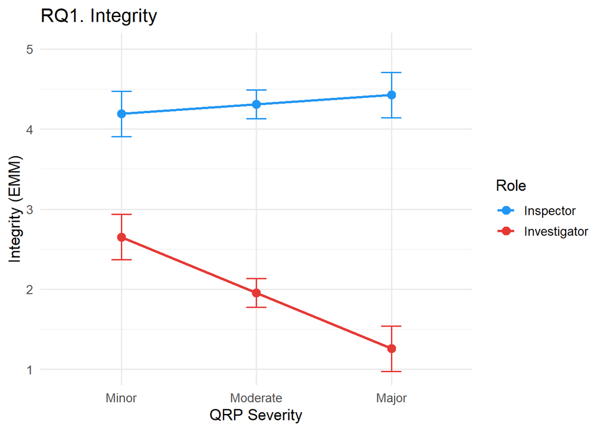

```r
emm_Integrity_df = as.data.frame(emmeans(T4, ~ role_ec * severity_num,
                                       at = list(severity_num = c(-1, 0, 1))))
emm_Integrity_df = emm_Integrity_df %>%
  mutate(
    Role     = if_else(role_ec == 1, "Inspector", "Investigator"),
    Severity = factor(severity_num, levels = c(-1, 0, 1),
                      labels = c("Minor", "Moderate", "Major"))
  )

ggplot(emm_Integrity_df, aes(x = Severity, y = emmean, color = Role, group = Role)) +
  geom_line(linewidth = 1) +
  geom_point(size = 3) +
  geom_errorbar(aes(ymin = lower.CL, ymax = upper.CL), width = 0.15) +
  scale_color_manual(values = c("Inspector" = "#2196F3", "Investigator" = "#E53935")) +
  labs(title = "RQ1. Integrity",
       y = "Integrity (EMM)", x = "QRP Severity") +
  theme_minimal(base_size = 13) +
  coord_cartesian(ylim = c(1, 5))
```

## STEP 5: RQ2 — Likeability models (H2a: main effect of role; H2b: role × severity)

Research Question 2: How is likeability influenced by role and QRP severity? • Hypothesis 2a: Investigators will be rated more likable than inspectors. • Hypothesis 2b: At low QRP severity, investigators will be rated as more likeable than inspectors, but at high QRP severity, inspectors will be rated as more likeable than investigators.

Research Questions 1–2: Integrity and Likeability Step-up MLMs will test Role, Severity, and Role × Severity interaction:

Model 1: Integrity/Likeabilityijk = γ000 + γ100 (Researcherj) + ν0k + μ0jk + εijk Model 2: Integrity/Likeabilityijk = γ000 + γ010 (Severityk) + ν0k + μ0k + εijk Model 3: Integrity/Likeabilityijk = γ000 + γ100 (Researcherj) + γ010 (Severityk) + ν0k + μ0jk + εijk Model 4: Integrity/Likeabilityijk = γ000 + γ100 (Researcherj) + γ010 (Severityk) + γ110(Researcherj × Severityk) + ν0k + μ0jk + εijk

```r
# Model 1: Role only (H2a)
L1 = lmer(
  likeability ~ role_ec + (1 | responseid),
  data = tl_dat, REML = FALSE,
  control = lmerControl(optimizer = "bobyqa")
)

# Model 2: Severity only
L2 = lmer(
  likeability ~ severity_num + (1 | responseid),
  data = tl_dat, REML = FALSE,
  control = lmerControl(optimizer = "bobyqa")
)
```

```
## boundary (singular) fit: see help('isSingular')
```

```r
# Model 3: Role + Severity (additive)
L3 = lmer(
  likeability ~ role_ec + severity_num + (1 | responseid),
  data = tl_dat, REML = FALSE,
  control = lmerControl(optimizer = "bobyqa")
)

# Model 4: Role × Severity interaction (H2b)
L4 = lmer(
  likeability ~ role_ec * severity_num + (1 | responseid),
  data = tl_dat, REML = FALSE,
  control = lmerControl(optimizer = "bobyqa")
)

# model comparison
anova(L1, L2, L3, L4)
```

```
## Data: tl_dat
## Models:
## L1: likeability ~ role_ec + (1 | responseid)
## L2: likeability ~ severity_num + (1 | responseid)
## L3: likeability ~ role_ec + severity_num + (1 | responseid)
## L4: likeability ~ role_ec * severity_num + (1 | responseid)
##    npar    AIC    BIC  logLik -2*log(L)   Chisq Df Pr(>Chisq)
## L1    4 7055.7 7079.3 -3523.9    7047.7
## L2    4 8184.8 8208.4 -4088.4    8176.8    0.00  0
## L3    5 6996.9 7026.4 -3493.5    6986.9 1189.87  1  < 2.2e-16 ***
## L4    6 6725.2 6760.5 -3356.6    6713.2  273.79  1  < 2.2e-16 ***
## ---
## Signif. codes:  0 '***' 0.001 '**' 0.01 '*' 0.05 '.' 0.1 ' ' 1
```

```r
summary(L1)
```

```
## Linear mixed model fit by maximum likelihood . t-tests use Satterthwaite's
##   method [lmerModLmerTest]
## Formula: likeability ~ role_ec + (1 | responseid)
##    Data: tl_dat
## Control: lmerControl(optimizer = "bobyqa")
##
##       AIC       BIC    logLik -2*log(L)  df.resid
##    7055.7    7079.3   -3523.9    7047.7      2674
##
## Scaled residuals:
##      Min       1Q   Median       3Q      Max
## -3.10808 -0.88143  0.03806  0.59280  2.81178
##
## Random effects:
##  Groups     Name        Variance Std.Dev.
##  responseid (Intercept) 0.001335 0.03654
##  Residual               0.812366 0.90131
## Number of obs: 2678, groups:  responseid, 448
##
## Fixed effects:
##              Estimate Std. Error        df t value Pr(>|t|)
## (Intercept) 3.136e+00  1.750e-02 4.476e+02   179.2   <2e-16 ***
## role_ec     6.670e-01  1.742e-02 2.232e+03    38.3   <2e-16 ***
## ---
## Signif. codes:  0 '***' 0.001 '**' 0.01 '*' 0.05 '.' 0.1 ' ' 1
##
## Correlation of Fixed Effects:
##         (Intr)
## role_ec 0.001
```

```r
summary(L2)
```

```
## Linear mixed model fit by maximum likelihood . t-tests use Satterthwaite's
##   method [lmerModLmerTest]
## Formula: likeability ~ severity_num + (1 | responseid)
##    Data: tl_dat
## Control: lmerControl(optimizer = "bobyqa")
##
##       AIC       BIC    logLik -2*log(L)  df.resid
##    8184.8    8208.4   -4088.4    8176.8      2674
##
## Scaled residuals:
##     Min      1Q  Median      3Q     Max
## -2.0656 -0.7188 -0.1215  0.7764  1.8226
##
## Random effects:
##  Groups     Name        Variance Std.Dev.
##  responseid (Intercept) 0.00     0.000
##  Residual               1.24     1.114
## Number of obs: 2678, groups:  responseid, 448
##
## Fixed effects:
##                Estimate Std. Error         df t value Pr(>|t|)
## (Intercept)     3.13530    0.02152 2678.00000 145.680  < 2e-16 ***
## severity_num   -0.16523    0.02637 2678.00000  -6.266  4.3e-10 ***
## ---
## Signif. codes:  0 '***' 0.001 '**' 0.01 '*' 0.05 '.' 0.1 ' ' 1
##
## Correlation of Fixed Effects:
##             (Intr)
## severity_nm -0.001
## optimizer (bobyqa) convergence code: 0 (OK)
## boundary (singular) fit: see help('isSingular')
```

```r
summary(L3)
```

```
## Linear mixed model fit by maximum likelihood . t-tests use Satterthwaite's
##   method [lmerModLmerTest]
## Formula: likeability ~ role_ec + severity_num + (1 | responseid)
##    Data: tl_dat
## Control: lmerControl(optimizer = "bobyqa")
##
##       AIC       BIC    logLik -2*log(L)  df.resid
##    6996.9    7026.4   -3493.5    6986.9      2673
##
## Scaled residuals:
##     Min      1Q  Median      3Q     Max
## -3.2988 -0.7082  0.0415  0.6156  3.0145
##
## Random effects:
##  Groups     Name        Variance Std.Dev.
##  responseid (Intercept) 0.004913 0.07009
##  Residual               0.790602 0.88916
## Number of obs: 2678, groups:  responseid, 448
##
## Fixed effects:
##                Estimate Std. Error         df t value Pr(>|t|)
## (Intercept)     3.13578    0.01750  447.74067 179.198  < 2e-16 ***
## role_ec         0.66701    0.01718 2232.36570  38.820  < 2e-16 ***
## severity_num   -0.16522    0.02105 2234.28947  -7.849 6.47e-15 ***
## ---
## Signif. codes:  0 '***' 0.001 '**' 0.01 '*' 0.05 '.' 0.1 ' ' 1
##
## Correlation of Fixed Effects:
##             (Intr) role_c
## role_ec      0.001
## severity_nm -0.001  0.000
```

```r
summary(L4)
```

```
## Linear mixed model fit by maximum likelihood . t-tests use Satterthwaite's
##   method [lmerModLmerTest]
## Formula: likeability ~ role_ec * severity_num + (1 | responseid)
##    Data: tl_dat
## Control: lmerControl(optimizer = "bobyqa")
##
##       AIC       BIC    logLik -2*log(L)  df.resid
##    6725.2    6760.5   -3356.6    6713.2      2672
##
## Scaled residuals:
##     Min      1Q  Median      3Q     Max
## -3.5343 -0.6463  0.0430  0.6589  3.5490
##
## Random effects:
##  Groups     Name        Variance Std.Dev.
##  responseid (Intercept) 0.02012  0.1418
##  Residual               0.69933  0.8363
## Number of obs: 2678, groups:  responseid, 448
##
## Fixed effects:
##                        Estimate Std. Error         df t value Pr(>|t|)
## (Intercept)             3.13571    0.01750  447.67619 179.213   <2e-16 ***
## role_ec                 0.66675    0.01616 2232.17270  41.259   <2e-16 ***
## severity_num           -0.16484    0.01980 2234.03163  -8.325   <2e-16 ***
## role_ec:severity_num    0.33792    0.01980 2232.46255  17.067   <2e-16 ***
## ---
## Signif. codes:  0 '***' 0.001 '**' 0.01 '*' 0.05 '.' 0.1 ' ' 1
##
## Correlation of Fixed Effects:
##             (Intr) role_c svrty_
## role_ec      0.001
## severity_nm -0.001  0.000
## rl_c:svrty_  0.000 -0.001  0.001
```

Random slope testing for likeability — same logic as Integrity above.

```r
L4_max1 = lmer(
  likeability ~ role_ec * severity_num + (1 + role_ec * severity_num | responseid),
  data = tl_dat, REML = FALSE,
  control = lmerControl(optimizer = "bobyqa")
)
isSingular(L4_max1)
```

```
## [1] FALSE
```

```r
L4_max2 = lmer(
  likeability ~ role_ec * severity_num + (1 + role_ec + severity_num | responseid),
  data = tl_dat, REML = FALSE,
  control = lmerControl(optimizer = "bobyqa")
)
```

```
## boundary (singular) fit: see help('isSingular')
```

```r
isSingular(L4_max2)
```

```
## [1] TRUE
```

```r
L4_max3 = lmer(
  likeability ~ role_ec * severity_num + (1 + role_ec | responseid),
  data = tl_dat, REML = FALSE,
  control = lmerControl(optimizer = "bobyqa")
)
isSingular(L4_max3)
```

```
## [1] FALSE
```

```r
summary(L4_max1)
```

```
## Linear mixed model fit by maximum likelihood . t-tests use Satterthwaite's
##   method [lmerModLmerTest]
## Formula: likeability ~ role_ec * severity_num + (1 + role_ec * severity_num |
##     responseid)
##    Data: tl_dat
## Control: lmerControl(optimizer = "bobyqa")
##
##       AIC       BIC    logLik -2*log(L)  df.resid
##    6185.3    6273.7   -3077.7    6155.3      2663
##
## Scaled residuals:
##     Min      1Q  Median      3Q     Max
## -4.9532 -0.4833  0.0196  0.5209  4.1920
##
## Random effects:
##  Groups     Name                 Variance Std.Dev. Corr
##  responseid (Intercept)          0.075455 0.27469
##             role_ec              0.242917 0.49287   0.26
##             severity_num         0.005489 0.07409  -0.53 -0.94
##             role_ec:severity_num 0.045547 0.21342  -0.03  0.23 -0.33
##  Residual                        0.367035 0.60583
## Number of obs: 2678, groups:  responseid, 448
##
## Fixed effects:
##                        Estimate Std. Error         df t value Pr(>|t|)
## (Intercept)             3.13592    0.01749  447.75952  179.29   <2e-16 ***
## role_ec                 0.66762    0.02608  447.28607   25.59   <2e-16 ***
## severity_num           -0.16479    0.01477 1053.96125  -11.16   <2e-16 ***
## role_ec:severity_num    0.33796    0.01755  446.68188   19.26   <2e-16 ***
## ---
## Signif. codes:  0 '***' 0.001 '**' 0.01 '*' 0.05 '.' 0.1 ' ' 1
##
## Correlation of Fixed Effects:
##             (Intr) role_c svrty_
## role_ec      0.176
## severity_nm -0.095 -0.201
## rl_c:svrty_ -0.011  0.119 -0.044
```

```r
summary(L4_max2)
```

```
## Linear mixed model fit by maximum likelihood . t-tests use Satterthwaite's
##   method [lmerModLmerTest]
## Formula: likeability ~ role_ec * severity_num + (1 + role_ec + severity_num |
##     responseid)
##    Data: tl_dat
## Control: lmerControl(optimizer = "bobyqa")
##
##       AIC       BIC    logLik -2*log(L)  df.resid
##    6213.3    6278.1   -3095.7    6191.3      2667
##
## Scaled residuals:
##     Min      1Q  Median      3Q     Max
## -4.7829 -0.5271  0.0196  0.5526  4.6832
##
## Random effects:
##  Groups     Name         Variance Std.Dev. Corr
##  responseid (Intercept)  0.067893 0.26056
##             role_ec      0.235462 0.48524   0.28
##             severity_num 0.005203 0.07213  -0.55 -0.96
##  Residual                0.412640 0.64237
## Number of obs: 2678, groups:  responseid, 448
##
## Fixed effects:
##                        Estimate Std. Error         df t value Pr(>|t|)
## (Intercept)             3.13590    0.01749  447.97308  179.25   <2e-16 ***
## role_ec                 0.66763    0.02609  447.38987   25.59   <2e-16 ***
## severity_num           -0.16484    0.01559 1332.51532  -10.57   <2e-16 ***
## role_ec:severity_num    0.33797    0.01521 1785.73380   22.21   <2e-16 ***
## ---
## Signif. codes:  0 '***' 0.001 '**' 0.01 '*' 0.05 '.' 0.1 ' ' 1
##
## Correlation of Fixed Effects:
##             (Intr) role_c svrty_
## role_ec      0.176
## severity_nm -0.085 -0.185
## rl_c:svrty_  0.000  0.000  0.001
## optimizer (bobyqa) convergence code: 0 (OK)
## boundary (singular) fit: see help('isSingular')
```

```r
summary(L4_max3)
```

```
## Linear mixed model fit by maximum likelihood . t-tests use Satterthwaite's
##   method [lmerModLmerTest]
## Formula: likeability ~ role_ec * severity_num + (1 + role_ec | responseid)
##    Data: tl_dat
## Control: lmerControl(optimizer = "bobyqa")
##
##       AIC       BIC    logLik -2*log(L)  df.resid
##    6225.3    6272.5   -3104.7    6209.3      2670
##
## Scaled residuals:
##     Min      1Q  Median      3Q     Max
## -4.4901 -0.5515  0.0110  0.5612  4.6092
##
## Random effects:
##  Groups     Name        Variance Std.Dev. Corr
##  responseid (Intercept) 0.06691  0.2587
##             role_ec     0.23444  0.4842   0.28
##  Residual               0.41810  0.6466
## Number of obs: 2678, groups:  responseid, 448
##
## Fixed effects:
##                        Estimate Std. Error         df t value Pr(>|t|)
## (Intercept)             3.13594    0.01749  447.65972  179.30   <2e-16 ***
## role_ec                 0.66768    0.02608  447.36805   25.60   <2e-16 ***
## severity_num           -0.16472    0.01531 1786.13989  -10.76   <2e-16 ***
## role_ec:severity_num    0.33804    0.01531 1785.71796   22.07   <2e-16 ***
## ---
## Signif. codes:  0 '***' 0.001 '**' 0.01 '*' 0.05 '.' 0.1 ' ' 1
##
## Correlation of Fixed Effects:
##             (Intr) role_c svrty_
## role_ec      0.175
## severity_nm -0.001  0.000
## rl_c:svrty_  0.000  0.000  0.001
```

```r
# Use whichever is the most complex non-singular model as the structure
# for L1-L4 above; if all are singular, the intercept-only structure
# already used is justified and should be cited as such.
```

Planned contrasts: Bonferroni α = .001

```r
emm_like_role = emmeans(L4, pairwise ~ role_ec | severity_num,
                          at = list(severity_num = c(-1, 0, 1)),
                          adjust = "bonferroni")
summary(emm_like_role$contrasts)
```

```
## severity_num = -1:
##  contrast               estimate     SE   df t.ratio p.value
##  (role_ec-1) - role_ec1   -0.658 0.0512 2235 -12.852 <0.0001
##
## severity_num =  0:
##  contrast               estimate     SE   df t.ratio p.value
##  (role_ec-1) - role_ec1   -1.333 0.0323 2235 -41.232 <0.0001
##
## severity_num =  1:
##  contrast               estimate     SE   df t.ratio p.value
##  (role_ec-1) - role_ec1   -2.009 0.0511 2235 -39.302 <0.0001
##
## Degrees-of-freedom method: kenward-roger
```

```r
eff_size(emmeans(L4, ~ role_ec | severity_num,
                  at = list(severity_num = c(-1, 0, 1))),
         sigma = sigma(L4), edf = df.residual(L4))
```

```
## severity_num = -1:
##  contrast               effect.size     SE   df lower.CL upper.CL
##  (role_ec-1) - role_ec1      -0.786 0.0621 2615   -0.908   -0.665
##
## severity_num =  0:
##  contrast               effect.size     SE   df lower.CL upper.CL
##  (role_ec-1) - role_ec1      -1.595 0.0444 1342   -1.682   -1.507
##
## severity_num =  1:
##  contrast               effect.size     SE   df lower.CL upper.CL
##  (role_ec-1) - role_ec1      -2.403 0.0694 2614   -2.539   -2.267
##
## sigma used for effect sizes: 0.8363
## Degrees-of-freedom method: inherited from kenward-roger when re-gridding
## Confidence level used: 0.95
```

Plot Role × Severity for likeability

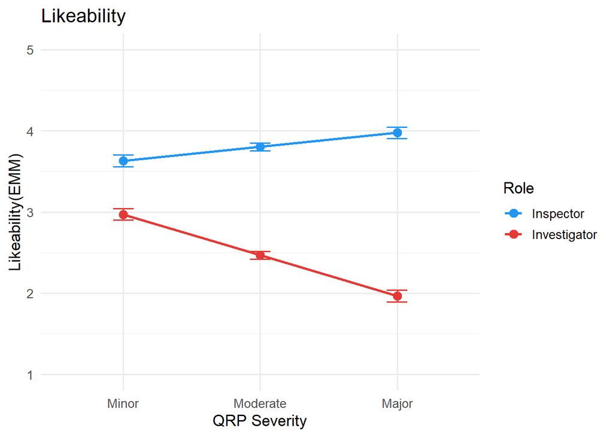

```r
emm_like_df = as.data.frame(emmeans(L4, ~ role_ec * severity_num,
                                      at = list(severity_num = c(-1, 0, 1)))) %>%
  mutate(
    Role     = if_else(role_ec == 1, "Inspector", "Investigator"),
    Severity = factor(severity_num, levels = c(-1, 0, 1),
                      labels = c("Minor", "Moderate", "Major"))
  )

ggplot(emm_like_df, aes(x = Severity, y = emmean, color = Role, group = Role)) +
  geom_line(linewidth = 1) +
  geom_point(size = 3) +
  geom_errorbar(aes(ymin = lower.CL, ymax = upper.CL), width = 0.15) +
  scale_color_manual(values = c("Inspector" = "#2196F3", "Investigator" = "#E53935")) +
  labs(title = "Likeability",
       y = "Likeability(EMM)", x = "QRP Severity") +
  theme_minimal(base_size = 13) +
  coord_cartesian(ylim = c(1, 5))
```

## STEP 6: RQ3 — Perceived Trueness of the Finding (H3: severity → trueness)

Research Question 3: Trueness of Findings Model FT1: Truenessijk= γ000 + γ010 (Severityk) + ν0k + μ0j + εijk

```r
# Trueness is only for investigators, one item per vignette
trueness_dat = filtered_by_age %>%
  transmute(
    responseid,
    minor    = parse_num(kcon),
    moderate = parse_num(hcon),
    major    = parse_num(xcon)
  ) %>%
  pivot_longer(
    cols      = c(minor, moderate, major),
    names_to  = "severity",
    values_to = "trueness"
  ) %>%
  mutate(
    severity     = factor(severity, levels = c("minor", "moderate", "major")),
    severity_num = case_when(
      severity == "minor"    ~ -1,
      severity == "moderate" ~  0,
      severity == "major"    ~  1
    ),
    responseid = factor(responseid),
    trueness_c = trueness - 3
  )

# Descriptives
trueness_dat %>%
  group_by(severity) %>%
  summarise(
    n  = sum(!is.na(trueness)),
    M  = round(mean(trueness, na.rm = TRUE), 2),
    SD = round(sd(trueness,   na.rm = TRUE), 2),
    .groups = "drop"
  ) %>%
  kable(caption = "Trueness Descriptives by QRP Severity") %>%
  kable_styling()
```

Trueness Descriptives by QRP Severity

| severity | n | M | SD |
| --- | --- | --- | --- |
| minor | 446 | 2.98 | 0.91 |
| moderate | 447 | 1.86 | 0.92 |
| major | 447 | 1.53 | 0.88 |

Model FT1: Trueness ~ Severity (H3)

```r
FT1 = lmer(
  trueness_c ~ severity_num + (1 | responseid) + (1 | severity),
  data    = trueness_dat,
  REML    = FALSE,
  control = lmerControl(optimizer = "bobyqa")
)

summary(FT1)
```

```
## Linear mixed model fit by maximum likelihood . t-tests use Satterthwaite's
##   method [lmerModLmerTest]
## Formula: trueness_c ~ severity_num + (1 | responseid) + (1 | severity)
##    Data: trueness_dat
## Control: lmerControl(optimizer = "bobyqa")
##
##       AIC       BIC    logLik -2*log(L)  df.resid
##    3503.7    3529.7   -1746.8    3493.7      1335
##
## Scaled residuals:
##     Min      1Q  Median      3Q     Max
## -2.7309 -0.6556 -0.0754  0.4459  4.0079
##
## Random effects:
##  Groups     Name        Variance Std.Dev.
##  responseid (Intercept) 0.16689  0.4085
##  severity   (Intercept) 0.03313  0.1820
##  Residual               0.65229  0.8076
## Number of obs: 1340, groups:  responseid, 448; severity, 3
##
## Fixed effects:
##              Estimate Std. Error      df t value Pr(>|t|)
## (Intercept)   -0.8771     0.1091  3.1960  -8.040  0.00318 **
## severity_num  -0.7213     0.1315  2.9993  -5.485  0.01193 *
## ---
## Signif. codes:  0 '***' 0.001 '**' 0.01 '*' 0.05 '.' 0.1 ' ' 1
##
## Correlation of Fixed Effects:
##             (Intr)
## severity_nm 0.000
```

```r
isSingular(FT1)
```

```
## [1] FALSE
```

```r
# Planned contrasts across severity levels
emm_trueness = emmeans(FT1, pairwise ~ severity_num,
                         at     = list(severity_num = c(-1, 0, 1)),
                         adjust = "bonferroni")
summary(emm_trueness$contrasts)
```

```
##  contrast                         estimate    SE   df t.ratio p.value
##  (severity_num-1) - severity_num0    0.721 0.227 8.81   3.183  0.0343
##  (severity_num-1) - severity_num1    1.443 0.453 8.81   3.183  0.0343
##  severity_num0 - severity_num1       0.721 0.227 8.81   3.183  0.0343
##
## Degrees-of-freedom method: kenward-roger
## P value adjustment: bonferroni method for 3 tests
```

```r
eff_size(emmeans(FT1, ~ severity_num, at = list(severity_num = c(-1, 0, 1))),
         sigma = sigma(FT1), edf = df.residual(FT1))
```

```
##  contrast                         effect.size    SE   df lower.CL upper.CL
##  (severity_num-1) - severity_num0       0.893 0.281 8.64    0.253     1.53
##  (severity_num-1) - severity_num1       1.786 0.562 8.74    0.509     3.06
##  severity_num0 - severity_num1          0.893 0.281 8.64    0.253     1.53
##
## sigma used for effect sizes: 0.8076
## Degrees-of-freedom method: inherited from kenward-roger when re-gridding
## Confidence level used: 0.95
```

Plot trueness by severity

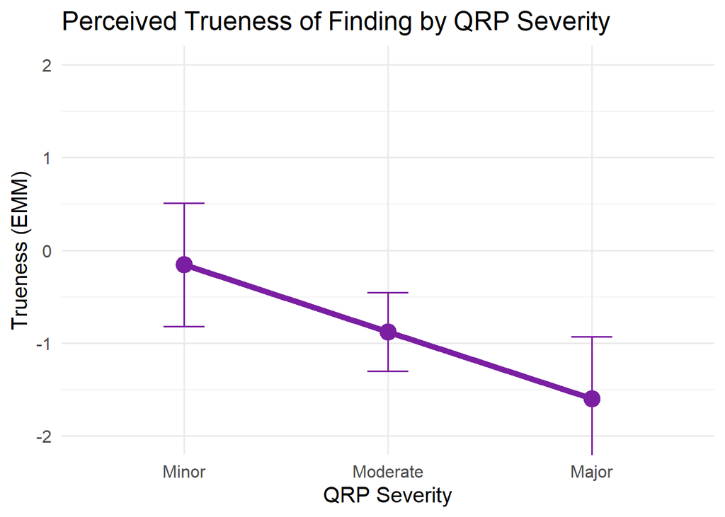

```r
emm_true_df = as.data.frame(
  emmeans(FT1, ~ severity_num, at = list(severity_num = c(-1, 0, 1)))
) %>%
  mutate(Severity = factor(severity_num, levels = c(-1, 0, 1),
                            labels = c("Minor", "Moderate", "Major")))

ggplot(emm_true_df, aes(x = Severity, y = emmean, group = 1)) +
  geom_line(linewidth = 2, color = "#7B1FA2") +
  geom_point(size = 5, color = "#7B1FA2") +
  geom_errorbar(aes(ymin = lower.CL, ymax = upper.CL), width = 0.20,
                color = "#7B1FA2") +
  labs(title = "Perceived Trueness of Finding by QRP Severity",
       y = "Trueness (EMM)", x = "QRP Severity") +
  theme_minimal(base_size = 15) +
  coord_cartesian(ylim = c(-2, 2))
```

## STEP 7: Robustness checks — demographic covariates

```r
# Attach demographics to tl_dat
demo_dat = filtered_by_age %>%
  transmute(
    responseid = responseid,
    gender     = factor(`gender.identity`),
    political  = factor(political, levels = c(
      "Strongly Liberal", "Liberal", "Lean Liberal",
      "Centrist",
      "Lean Conservative", "Conservative", "Strongly Conservative"
    )),
    religion   = factor(religion)
  )

tl_robust = tl_dat %>%
  mutate(responseid = as.character(responseid)) %>%
  left_join(demo_dat, by = "responseid") %>%
  mutate(responseid = factor(responseid))


# Integrity robustness model (Model 4 + demographics)
T4_robust = lmer(
  Integrity ~ role_ec * severity_num + gender + political + religion +
    (1 | responseid) + (1 | severity),
  data    = tl_robust,
  REML    = FALSE,
  control = lmerControl(optimizer = "bobyqa")
)

L4_robust = lmer(
  likeability ~ role_ec * severity_num + gender + political + religion +
    (1 | responseid) + (1 | severity),
  data    = tl_robust,
  REML    = FALSE,
  control = lmerControl(optimizer = "bobyqa")
)
```

```
## boundary (singular) fit: see help('isSingular')
```

```r
summary(L4_robust)
```

```
## Linear mixed model fit by maximum likelihood . t-tests use Satterthwaite's
##   method [lmerModLmerTest]
## Formula:
## likeability ~ role_ec * severity_num + gender + political + religion +
##     (1 | responseid) + (1 | severity)
##    Data: tl_robust
## Control: lmerControl(optimizer = "bobyqa")
##
##       AIC       BIC    logLik -2*log(L)  df.resid
##    6468.7    6591.6   -3213.4    6426.7      2553
##
## Scaled residuals:
##     Min      1Q  Median      3Q     Max
## -3.4291 -0.6614  0.0299  0.6823  3.5356
##
## Random effects:
##  Groups     Name        Variance  Std.Dev.
##  responseid (Intercept) 1.516e-02 1.231e-01
##  severity   (Intercept) 2.947e-79 5.429e-40
##  Residual               6.966e-01 8.346e-01
## Number of obs: 2574, groups:  responseid, 429; severity, 3
##
## Fixed effects:
##                                     Estimate Std. Error         df t value
## (Intercept)                          3.06758    0.09868  428.99991  31.086
## role_ec                              0.66608    0.01645 2144.99983  40.490
## severity_num                        -0.16725    0.02015 2144.99983  -8.301
## genderNon-binary / third gender     -0.04983    0.26557  428.99991  -0.188
## genderPrefer not to say              0.33156    0.26587  428.99991   1.247
## genderWoman                          0.04510    0.04645  428.99991   0.971
## politicalLiberal                     0.02229    0.09543  428.99991   0.234
## politicalLean Liberal               -0.05978    0.10167  428.99991  -0.588
## politicalCentrist                   -0.07258    0.09153  428.99991  -0.793
## politicalLean Conservative          -0.06792    0.09481  428.99991  -0.716
## politicalConservative               -0.01892    0.09072  428.99991  -0.209
## politicalStrongly Conservative       0.01602    0.10003  428.99991   0.160
## religionIslam                        0.50500    0.36740  428.99991   1.374
## religionJudaism                      0.16395    0.26011  428.99991   0.630
## religionNot Affiliated              -0.04004    0.06584  428.99991  -0.608
## religionOther                        0.18648    0.08167  428.99991   2.283
```

[output cut: 8 more lines]

```
## genderWoman                         0.3321
## politicalLiberal                    0.8154
## politicalLean Liberal               0.5568
## politicalCentrist                   0.4283
## politicalLean Conservative          0.4741
## politicalConservative               0.8349
## politicalStrongly Conservative      0.8728
## religionIslam                       0.1700
## religionJudaism                     0.5288
## religionNot Affiliated              0.5434
## religionOther                       0.0229 *
## religionProtestantism (Christian)   0.0531 .
## role_ec:severity_num                <2e-16 ***
## ---
## Signif. codes:  0 '***' 0.001 '**' 0.01 '*' 0.05 '.' 0.1 ' ' 1
```

```
##
## Correlation matrix not shown by default, as p = 18 > 12.
## Use print(x, correlation=TRUE)  or
##     vcov(x)        if you need it
```

```
## optimizer (bobyqa) convergence code: 0 (OK)
## boundary (singular) fit: see help('isSingular')
```

```r
# Compare role_ec * severity_num effect with and without demographics
summary(T4_robust)
```

```
## Linear mixed model fit by maximum likelihood . t-tests use Satterthwaite's
##   method [lmerModLmerTest]
## Formula: Integrity ~ role_ec * severity_num + gender + political + religion +
##     (1 | responseid) + (1 | severity)
##    Data: tl_robust
## Control: lmerControl(optimizer = "bobyqa")
##
##       AIC       BIC    logLik -2*log(L)  df.resid
##    6013.2    6136.1   -2985.6    5971.2      2553
##
## Scaled residuals:
##     Min      1Q  Median      3Q     Max
## -4.5141 -0.5837  0.0109  0.6688  4.7355
##
## Random effects:
##  Groups     Name        Variance Std.Dev.
##  responseid (Intercept) 0.003712 0.06092
##  severity   (Intercept) 0.005711 0.07557
##  Residual               0.590486 0.76843
## Number of obs: 2574, groups:  responseid, 429; severity, 3
##
## Fixed effects:
##                                     Estimate Std. Error         df t value
## (Intercept)                        3.173e+00  9.737e-02  5.435e+01  32.590
## role_ec                            1.178e+00  1.515e-02  2.143e+03  77.771
## severity_num                      -2.927e-01  5.656e-02  3.000e+00  -5.175
## genderNon-binary / third gender   -2.493e-01  2.342e-01  4.282e+02  -1.064
## genderPrefer not to say           -1.395e-01  2.345e-01  4.282e+02  -0.595
## genderWoman                       -9.858e-03  4.097e-02  4.282e+02  -0.241
## politicalLiberal                  -6.320e-02  8.417e-02  4.282e+02  -0.751
## politicalLean Liberal             -1.376e-01  8.968e-02  4.282e+02  -1.535
## politicalCentrist                 -1.032e-01  8.074e-02  4.282e+02  -1.278
## politicalLean Conservative        -9.914e-02  8.363e-02  4.282e+02  -1.185
## politicalConservative             -6.054e-02  8.002e-02  4.282e+02  -0.757
## politicalStrongly Conservative    -5.594e-02  8.823e-02  4.282e+02  -0.634
## religionIslam                      3.190e-01  3.241e-01  4.282e+02   0.984
## religionJudaism                    5.255e-02  2.294e-01  4.282e+02   0.229
## religionNot Affiliated             5.021e-04  5.808e-02  4.282e+02   0.009
## religionOther                      1.338e-01  7.204e-02  4.282e+02   1.857
## religionProtestantism (Christian)  6.880e-02  3.994e-02  4.282e+02   1.723
## role_ec:severity_num               4.163e-01  1.855e-02  2.143e+03  22.441
##                                   Pr(>|t|)
## (Intercept)                         <2e-16 ***
## role_ec                             <2e-16 ***
## severity_num                        0.0140 *
## genderNon-binary / third gender     0.2878
## genderPrefer not to say             0.5523
## genderWoman                         0.8100
## politicalLiberal                    0.4532
## politicalLean Liberal               0.1256
## politicalCentrist                   0.2019
## politicalLean Conservative          0.2365
## politicalConservative               0.4497
## politicalStrongly Conservative      0.5264
## religionIslam                       0.3256
## religionJudaism                     0.8189
## religionNot Affiliated              0.9931
## religionOther                       0.0640 .
## religionProtestantism (Christian)   0.0857 .
## role_ec:severity_num                <2e-16 ***
## ---
## Signif. codes:  0 '***' 0.001 '**' 0.01 '*' 0.05 '.' 0.1 ' ' 1
```

```
##
## Correlation matrix not shown by default, as p = 18 > 12.
## Use print(x, correlation=TRUE)  or
##     vcov(x)        if you need it
```

```r
summary(L4_robust)
```

```
## Linear mixed model fit by maximum likelihood . t-tests use Satterthwaite's
##   method [lmerModLmerTest]
## Formula:
## likeability ~ role_ec * severity_num + gender + political + religion +
##     (1 | responseid) + (1 | severity)
##    Data: tl_robust
## Control: lmerControl(optimizer = "bobyqa")
##
##       AIC       BIC    logLik -2*log(L)  df.resid
##    6468.7    6591.6   -3213.4    6426.7      2553
##
## Scaled residuals:
##     Min      1Q  Median      3Q     Max
## -3.4291 -0.6614  0.0299  0.6823  3.5356
##
## Random effects:
##  Groups     Name        Variance  Std.Dev.
##  responseid (Intercept) 1.516e-02 1.231e-01
##  severity   (Intercept) 2.947e-79 5.429e-40
##  Residual               6.966e-01 8.346e-01
## Number of obs: 2574, groups:  responseid, 429; severity, 3
##
## Fixed effects:
##                                     Estimate Std. Error         df t value
## (Intercept)                          3.06758    0.09868  428.99991  31.086
## role_ec                              0.66608    0.01645 2144.99983  40.490
## severity_num                        -0.16725    0.02015 2144.99983  -8.301
## genderNon-binary / third gender     -0.04983    0.26557  428.99991  -0.188
## genderPrefer not to say              0.33156    0.26587  428.99991   1.247
## genderWoman                          0.04510    0.04645  428.99991   0.971
## politicalLiberal                     0.02229    0.09543  428.99991   0.234
## politicalLean Liberal               -0.05978    0.10167  428.99991  -0.588
## politicalCentrist                   -0.07258    0.09153  428.99991  -0.793
## politicalLean Conservative          -0.06792    0.09481  428.99991  -0.716
## politicalConservative               -0.01892    0.09072  428.99991  -0.209
## politicalStrongly Conservative       0.01602    0.10003  428.99991   0.160
## religionIslam                        0.50500    0.36740  428.99991   1.374
## religionJudaism                      0.16395    0.26011  428.99991   0.630
## religionNot Affiliated              -0.04004    0.06584  428.99991  -0.608
## religionOther                        0.18648    0.08167  428.99991   2.283
```

[output cut: 8 more lines]

```
## genderWoman                         0.3321
## politicalLiberal                    0.8154
## politicalLean Liberal               0.5568
## politicalCentrist                   0.4283
## politicalLean Conservative          0.4741
## politicalConservative               0.8349
## politicalStrongly Conservative      0.8728
## religionIslam                       0.1700
## religionJudaism                     0.5288
## religionNot Affiliated              0.5434
## religionOther                       0.0229 *
## religionProtestantism (Christian)   0.0531 .
## role_ec:severity_num                <2e-16 ***
## ---
## Signif. codes:  0 '***' 0.001 '**' 0.01 '*' 0.05 '.' 0.1 ' ' 1
```

```
##
## Correlation matrix not shown by default, as p = 18 > 12.
## Use print(x, correlation=TRUE)  or
##     vcov(x)        if you need it
```

```
## optimizer (bobyqa) convergence code: 0 (OK)
## boundary (singular) fit: see help('isSingular')
```

```r
# Check if the interaction term stays significant in both
fixef(T4)[["role_ec:severity_num"]]
```

```
## [1] 0.40755
```

```r
fixef(T4_robust)[["role_ec:severity_num"]]
```

```
## [1] 0.4162782
```

```r
fixef(L4)[["role_ec:severity_num"]]
```

```
## [1] 0.3379173
```

```r
fixef(L4_robust)[["role_ec:severity_num"]]
```

```
## [1] 0.3455711
```

# ── APA Model Comparison Tables ──────────────────────────────────────────────

```r
# Helper: extract fixed effects from a model into a clean data frame
fe_table = function(model) {
  cf = summary(model)$coefficients
  ci = confint(model, method = "Wald")
  ci = ci[rownames(cf), ]
  data.frame(
    Parameter = rownames(cf),
    b         = round(cf[, "Estimate"], 2),
    SE        = round(cf[, "Std. Error"], 2),
    CI_low    = round(ci[, 1], 2),
    CI_high   = round(ci[, 2], 2),
    t         = round(cf[, "t value"], 2),
    p         = ifelse(cf[, "Pr(>|t|)"] < .001, "< .001",
                       formatC(cf[, "Pr(>|t|)"], digits = 3, format = "f"))
  )
}

# Helper: APA-friendly term labels
relabel = function(df) {
  df$Parameter = dplyr::recode(df$Parameter,
    "(Intercept)"          = "Intercept",
    "role_ec"              = "Role",
    "severity_num"         = "QRP Severity",
    "role_ec:severity_num" = "Role × QRP Severity"
  )
  df
}

# Helper: model fit summary table
fit_table = function(model_list, model_names) {
  do.call(rbind, lapply(seq_along(model_list), function(i) {
    m = model_list[[i]]
    data.frame(
      Model  = model_names[i],
      AIC    = round(AIC(m), 1),
      BIC    = round(BIC(m), 1),
      logLik = round(as.numeric(logLik(m)), 1)
    )
  }))
}

# ── TABLE 1: Integrity model fit ──────────────────────────────────────────────
fit_table(
  list(T1, T2, T3, T4),
  c("M1: Role", "M2: Severity", "M3: Role + Severity", "M4: Role × Severity")
) %>%
  kable(caption = "Table 1. Model Fit Indices for Step-Up Integrity Models",
        align = "lrrr") %>%
  kable_styling(full_width = FALSE, bootstrap_options = "condensed") %>%
  footnote(general = "Lower AIC/BIC indicates better model fit.")
```

Table 1. Model Fit Indices for Step-Up Integrity Models

| Model | AIC | BIC | logLik |
| --- | --- | --- | --- |
| M1: Role | 6691.6 | 6715.1 | -3341.8 |
| M2: Severity | 9588.9 | 9612.5 | -4790.5 |
| M3: Role + Severity | 6686.7 | 6716.2 | -3338.4 |
| M4: Role × Severity | 6232.8 | 6268.1 | -3110.4 |

Note:  
Lower AIC/BIC indicates better model fit.

```r
# ── TABLE 2: Integrity fixed effects (Model 4) ────────────────────────────────
fe_table(T4) %>%
  relabel() %>%
  mutate(`95% CI` = paste0("[", CI_low, ", ", CI_high, "]")) %>%
  select(Parameter, b, SE, `95% CI`, t, p) %>%
  kable(caption = "Table 2. Fixed Effects for Integrity Model 4 (Role × QRP Severity)",
        col.names = c("Parameter", "b", "SE", "95% CI", "t", "p"),
        align = "lrrrrr") %>%
  kable_styling(full_width = FALSE, bootstrap_options = "condensed") %>%
  footnote(general = "Role: inspector = 1, investigator = −1. QRP Severity: minor = −1, moderate = 0, major = 1.")
```

Table 2. Fixed Effects for Integrity Model 4 (Role × QRP Severity)

|  | Parameter | b | SE | 95% CI | t | p |
| --- | --- | --- | --- | --- | --- | --- |
| (Intercept) | Intercept | 3.13 | 0.05 | [3.04, 3.22] | 67.72 | < .001 |
| role_ec | Role | 1.18 | 0.01 | [1.15, 1.21] | 78.86 | < .001 |
| severity_num | QRP Severity | -0.29 | 0.06 | [-0.4, -0.18] | -5.10 | 0.015 |
| role_ec:severity_num | Role × QRP Severity | 0.41 | 0.02 | [0.37, 0.44] | 22.30 | < .001 |

Note:  
Role: inspector = 1, investigator = −1. QRP Severity: minor = −1, moderate = 0, major = 1.

```r
# ── TABLE 3: Likeability model fit ───────────────────────────────────────
fit_table(
  list(L1, L2, L3, L4),
  c("M1: Role", "M2: Severity", "M3: Role + Severity", "M4: Role × Severity")
) %>%
  kable(caption = "Table 3. Model Fit Indices for Step-Up Likeability Models",
        align = "lrrr") %>%
  kable_styling(full_width = FALSE, bootstrap_options = "condensed") %>%
  footnote(general = "Lower AIC/BIC indicates better model fit.")
```

Table 3. Model Fit Indices for Step-Up Likeability Models

| Model | AIC | BIC | logLik |
| --- | --- | --- | --- |
| M1: Role | 7055.7 | 7079.3 | -3523.9 |
| M2: Severity | 8184.8 | 8208.4 | -4088.4 |
| M3: Role + Severity | 6996.9 | 7026.4 | -3493.5 |
| M4: Role × Severity | 6725.2 | 6760.5 | -3356.6 |

Note:  
Lower AIC/BIC indicates better model fit.

```r
# ── TABLE 4: Likeability fixed effects (Model 4) ─────────────────────────
fe_table(L4) %>%
  relabel() %>%
  mutate(`95% CI` = paste0("[", CI_low, ", ", CI_high, "]")) %>%
  select(Parameter, b, SE, `95% CI`, t, p) %>%
  kable(caption = "Table 4. Fixed Effects for Likeability Model 4 (Role × QRP Severity)",
        col.names = c("Parameter", "b", "SE", "95% CI", "t", "p"),
        align = "lrrrrr") %>%
  kable_styling(full_width = FALSE, bootstrap_options = "condensed") %>%
  footnote(general = "Role: inspector = 1, investigator = −1. QRP Severity: minor = −1, moderate = 0, major = 1.")
```

Table 4. Fixed Effects for Likeability Model 4 (Role × QRP Severity)

|  | Parameter | b | SE | 95% CI | t | p |
| --- | --- | --- | --- | --- | --- | --- |
| (Intercept) | Intercept | 3.14 | 0.02 | [3.1, 3.17] | 179.21 | < .001 |
| role_ec | Role | 0.67 | 0.02 | [0.64, 0.7] | 41.26 | < .001 |
| severity_num | QRP Severity | -0.16 | 0.02 | [-0.2, -0.13] | -8.33 | < .001 |
| role_ec:severity_num | Role × QRP Severity | 0.34 | 0.02 | [0.3, 0.38] | 17.07 | < .001 |

Note:  
Role: inspector = 1, investigator = −1. QRP Severity: minor = −1, moderate = 0, major = 1.

```r
# ── TABLE 5: Trueness fixed effects (FT1) ────────────────────────────────
fe_table(FT1) %>%
  relabel() %>%
  mutate(`95% CI` = paste0("[", CI_low, ", ", CI_high, "]")) %>%
  select(Parameter, b, SE, `95% CI`, t, p) %>%
  kable(caption = "Table 5. Fixed Effects for Trueness Model FT1",
        col.names = c("Parameter", "b", "SE", "95% CI", "t", "p"),
        align = "lrrrrr") %>%
  kable_styling(full_width = FALSE, bootstrap_options = "condensed") %>%
  footnote(general = "Trueness centered at 3 (neutral midpoint). QRP Severity: minor = −1, moderate = 0, major = 1.")
```

Table 5. Fixed Effects for Trueness Model FT1

|  | Parameter | b | SE | 95% CI | t | p |
| --- | --- | --- | --- | --- | --- | --- |
| (Intercept) | Intercept | -0.88 | 0.11 | [-1.09, -0.66] | -8.04 | 0.003 |
| severity_num | QRP Severity | -0.72 | 0.13 | [-0.98, -0.46] | -5.48 | 0.012 |

Note:  
Trueness centered at 3 (neutral midpoint). QRP Severity: minor = −1, moderate = 0, major = 1.

## APA Step-Up Model Tables (side-by-side format)

```r
get_fe = function(model) {
  cf = summary(model)$coefficients
  list(
    b  = setNames(round(cf[,"Estimate"], 2),   rownames(cf)),
    se = setNames(round(cf[,"Std. Error"], 2), rownames(cf)),
    p  = setNames(cf[,"Pr(>|t|)"],             rownames(cf))
  )
}

fmt_p = function(p) {
  if (is.na(p)) return("")
  stars = ifelse(p < .001, "***", ifelse(p < .01, "**", ifelse(p < .05, "*", "")))
  paste0(formatC(p, digits = 3, format = "f"), stars)
}

cell = function(fe, term) {
  if (!term %in% names(fe$b)) return(c("", "", ""))
  c(as.character(fe$b[term]), as.character(fe$se[term]), fmt_p(fe$p[term]))
}
get_re = function(model) {
  vc = as.data.frame(lme4::VarCorr(model))
  setNames(round(vc$sdcor^2, 3), vc$grp)
}

get_icc = function(model) {
  vc = as.data.frame(lme4::VarCorr(model))
  total = sum(vc$vcov)
  setNames(round(vc$vcov / total, 3), vc$grp)
}

make_stepup_table = function(m0, m1, m2, m3, m4, caption_text, footnote_text) {

  models   = list(m0, m1, m2, m3, m4)
  fe_list  = lapply(models, get_fe)
  re_list  = lapply(models, get_re)
  icc_list = lapply(models, get_icc)

  term_labels = c(
    "(Intercept)"          = "Intercept",
    "role_ec"              = "Role",
    "severity_num"         = "QRP Severity",
    "role_ec:severity_num" = "Role × QRP Severity"
  )

  rows = lapply(names(term_labels), function(term) {
    cells = do.call(cbind, lapply(fe_list, function(fe) cell(fe, term)))
    data.frame(
      Parameter = term_labels[term],
      M0_b = cells[1,1], M0_se = cells[2,1], M0_p = cells[3,1],
      M1_b = cells[1,2], M1_se = cells[2,2], M1_p = cells[3,2],
      M2_b = cells[1,3], M2_se = cells[2,3], M2_p = cells[3,3],
      M3_b = cells[1,4], M3_se = cells[2,4], M3_p = cells[3,4],
      M4_b = cells[1,5], M4_se = cells[2,5], M4_p = cells[3,5],
      stringsAsFactors = FALSE
    )
  })
  fe_df = do.call(rbind, rows)

  re_grps = c("responseid" = "Participant variance",
               "severity"   = "Vignette variance",
               "Residual"   = "Residual variance")

  re_rows = lapply(names(re_grps), function(grp) {
    vals = sapply(re_list, function(re) {
      if (grp %in% names(re)) as.character(re[grp]) else "—"
    })
    data.frame(
      Parameter = re_grps[grp],
      M0_b = vals[1], M0_se = "", M0_p = "",
      M1_b = vals[2], M1_se = "", M1_p = "",
      M2_b = vals[3], M2_se = "", M2_p = "",
      M3_b = vals[4], M3_se = "", M3_p = "",
      M4_b = vals[5], M4_se = "", M4_p = "",
      stringsAsFactors = FALSE
    )
  })
  re_df = do.call(rbind, re_rows)

  icc_rows = lapply(names(re_grps)[1:2], function(grp) {
    vals = sapply(icc_list, function(ic) {
      if (grp %in% names(ic)) as.character(ic[grp]) else "—"
    })
    data.frame(
      Parameter = paste("ICC:", re_grps[grp]),
      M0_b = vals[1], M0_se = "", M0_p = "",
      M1_b = vals[2], M1_se = "", M1_p = "",
      M2_b = vals[3], M2_se = "", M2_p = "",
      M3_b = vals[4], M3_se = "", M3_p = "",
      M4_b = vals[5], M4_se = "", M4_p = "",
      stringsAsFactors = FALSE
    )
  })
  icc_df = do.call(rbind, icc_rows)

  fit_vals = sapply(models, function(m) c(round(AIC(m),1), round(BIC(m),1)))
  fit_df = data.frame(
    Parameter = c("AIC", "BIC"),
    M0_b = as.character(fit_vals[,1]), M0_se = "", M0_p = "",
    M1_b = as.character(fit_vals[,2]), M1_se = "", M1_p = "",
    M2_b = as.character(fit_vals[,3]), M2_se = "", M2_p = "",
    M3_b = as.character(fit_vals[,4]), M3_se = "", M3_p = "",
    M4_b = as.character(fit_vals[,5]), M4_se = "", M4_p = "",
    stringsAsFactors = FALSE
  )

  full_df = rbind(fe_df, re_df, icc_df, fit_df)

  full_df %>%
    kable(
      caption = caption_text,
      col.names = c("Parameter",
                    "b", "SE", "p",
                    "b", "SE", "p",
                    "b", "SE", "p",
                    "b", "SE", "p",
                    "b", "SE", "p"),
      align = c("l", rep("r", 15))
    ) %>%
    kable_styling(full_width = TRUE, font_size = 11,
                  bootstrap_options = c("condensed", "bordered")) %>%
    add_header_above(c(" " = 2,
                       "Model 0" = 3, "Model 1" = 3,
                       "Model 2" = 3, "Model 3" = 3,
                       "Model 4" = 3)) %>%
    footnote(general = footnote_text,
             general_title = "Note.",
             footnote_as_chunk = TRUE)
}

make_stepup_table(
  m0 = M0_Integrity, m1 = T1, m2 = T2, m3 = T3, m4 = T4,
  caption_text = "Table 1. Step-Up MLM Results for Integrity (Integrity) Ratings",
  footnote_text = "Role effect-coded: inspector = 1, investigator = −1. QRP Severity: minor = −1, moderate = 0, major = 1. * p < .05. ** p < .01. *** p < .001."
)
```

Table 1. Step-Up MLM Results for Integrity (Integrity) Ratings

|  | Parameter | Model 0 b | Model 0 SE | Model 0 p | Model 1 b | Model 1 SE | Model 1 p | Model 2 b | Model 2 SE | Model 2 p | Model 3 b | Model 3 SE | Model 3 p | Model 4 b | Model 4 SE | Model 4 p |
| --- | --- | --- | --- | --- | --- | --- | --- | --- | --- | --- | --- | --- | --- | --- | --- | --- |
| (Intercept) | Intercept | 3.13 | 0.18 | 0.003** | 3.13 | 0.14 | 0.000*** | 3.13 | 0.05 | 0.000*** | 3.13 | 0.05 | 0.000*** | 3.13 | 0.05 | 0.000*** |
| role_ec | Role |  |  |  | 1.18 | 0.02 | 0.000*** |  |  |  | 1.18 | 0.02 | 0.000*** | 1.18 | 0.01 | 0.000*** |
| severity_num | QRP Severity |  |  |  |  |  |  | -0.29 | 0.06 | 0.014* | -0.29 | 0.06 | 0.014* | -0.29 | 0.06 | 0.015* |
| role_ec:severity_num | Role × QRP Severity |  |  |  |  |  |  |  |  |  |  |  |  | 0.41 | 0.02 | 0.000*** |
| responseid | Participant variance | 0 |  |  | — |  |  | — |  |  | — |  |  | — |  |  |
| severity | Vignette variance | 0.091 |  |  | 0.061 |  |  | 0.004 |  |  | 0.006 |  |  | 0.006 |  |  |
| Residual | Residual variance | 2.093 |  |  | 0.707 |  |  | 2.093 |  |  | 0.707 |  |  | 0.596 |  |  |
| 1 | ICC: Participant variance | 0 |  |  | — |  |  | — |  |  | — |  |  | — |  |  |
| 2 | ICC: Vignette variance | 0.042 |  |  | 0.08 |  |  | 0.002 |  |  | 0.008 |  |  | 0.01 |  |  |
| 11 | AIC | 9597.6 |  |  | 6691.6 |  |  | 9588.9 |  |  | 6686.7 |  |  | 6232.8 |  |  |
| 21 | BIC | 9621.2 |  |  | 6715.1 |  |  | 9612.5 |  |  | 6716.2 |  |  | 6268.1 |  |  |

Note. Role effect-coded: inspector = 1, investigator = −1. QRP Severity: minor = −1, moderate = 0, major = 1. * p < .05. ** p < .01. *** p < .001.

```r
# ── LIKEABILITY TABLE
make_stepup_table(
  m0 = M0_like, m1 = L1, m2 = L2, m3 = L3, m4 = L4,
  caption_text = "Table 2. Step-Up MLM Results for Likeability Ratings",
  footnote_text = "Role effect-coded: inspector = 1, investigator = −1. QRP Severity: minor = −1, moderate = 0, major = 1. * p < .05. ** p < .01. *** p < .001."
)
```

Table 2. Step-Up MLM Results for Likeability Ratings

|  | Parameter | Model 0 b | Model 0 SE | Model 0 p | Model 1 b | Model 1 SE | Model 1 p | Model 2 b | Model 2 SE | Model 2 p | Model 3 b | Model 3 SE | Model 3 p | Model 4 b | Model 4 SE | Model 4 p |
| --- | --- | --- | --- | --- | --- | --- | --- | --- | --- | --- | --- | --- | --- | --- | --- | --- |
| (Intercept) | Intercept | 3.14 | 0.1 | 0.001*** | 3.14 | 0.02 | 0.000*** | 3.14 | 0.02 | 0.000*** | 3.14 | 0.02 | 0.000*** | 3.14 | 0.02 | 0.000*** |
| role_ec | Role |  |  |  | 0.67 | 0.02 | 0.000*** |  |  |  | 0.67 | 0.02 | 0.000*** | 0.67 | 0.02 | 0.000*** |
| severity_num | QRP Severity |  |  |  |  |  |  | -0.17 | 0.03 | 0.000*** | -0.17 | 0.02 | 0.000*** | -0.16 | 0.02 | 0.000*** |
| role_ec:severity_num | Role × QRP Severity |  |  |  |  |  |  |  |  |  |  |  |  | 0.34 | 0.02 | 0.000*** |
| responseid | Participant variance | 0 |  |  | 0.001 |  |  | 0 |  |  | 0.005 |  |  | 0.02 |  |  |
| severity | Vignette variance | 0.026 |  |  | — |  |  | — |  |  | — |  |  | — |  |  |
| Residual | Residual variance | 1.242 |  |  | 0.812 |  |  | 1.24 |  |  | 0.791 |  |  | 0.699 |  |  |
| 1 | ICC: Participant variance | 0 |  |  | 0.002 |  |  | 0 |  |  | 0.006 |  |  | 0.028 |  |  |
| 2 | ICC: Vignette variance | 0.021 |  |  | — |  |  | — |  |  | — |  |  | — |  |  |
| 11 | AIC | 8198.3 |  |  | 7055.7 |  |  | 8184.8 |  |  | 6996.9 |  |  | 6725.2 |  |  |
| 21 | BIC | 8221.8 |  |  | 7079.3 |  |  | 8208.4 |  |  | 7026.4 |  |  | 6760.5 |  |  |

Note. Role effect-coded: inspector = 1, investigator = −1. QRP Severity: minor = −1, moderate = 0, major = 1. * p < .05. ** p < .01. *** p < .001.

```r
# ── TRUENESS TABLE (single model) ─────────────────────────────────────────────
fe_ft1 = get_fe(FT1)
re_ft1 = get_re(FT1)
icc_ft1 = get_icc(FT1)

data.frame(
  Parameter = c("Intercept", "QRP Severity",
                "Participant variance", "Vignette variance", "Residual variance",
                "ICC: Participant", "ICC: Vignette",
                "AIC", "BIC"),
  b = c(
    as.character(fe_ft1$b["(Intercept)"]),
    as.character(fe_ft1$b["severity_num"]),
    ifelse("responseid" %in% names(re_ft1), as.character(re_ft1["responseid"]), "—"),
    ifelse("severity"   %in% names(re_ft1), as.character(re_ft1["severity"]),   "—"),
    ifelse("Residual"   %in% names(re_ft1), as.character(re_ft1["Residual"]),   "—"),
    ifelse("responseid" %in% names(icc_ft1), as.character(icc_ft1["responseid"]), "—"),
    ifelse("severity"   %in% names(icc_ft1), as.character(icc_ft1["severity"]),   "—"),
    as.character(round(AIC(FT1), 1)),
    as.character(round(BIC(FT1), 1))
  ),
  SE = c(
    as.character(fe_ft1$se["(Intercept)"]),
    as.character(fe_ft1$se["severity_num"]),
    "", "", "", "", "", "", ""
  ),
  p = c(
    fmt_p(fe_ft1$p["(Intercept)"]),
    fmt_p(fe_ft1$p["severity_num"]),
    "", "", "", "", "", "", ""
  ),
  stringsAsFactors = FALSE
) %>%
  kable(caption = "Table 3. MLM Results for Perceived Trueness of Finding (FT1)",
        col.names = c("Parameter", "b", "SE", "p"),
        align = c("l", "r", "r", "r")) %>%
  kable_styling(full_width = FALSE, font_size = 11,
                bootstrap_options = c("condensed", "bordered")) %>%
  footnote(general = "Trueness centered at 3 (neutral). QRP Severity: minor = −1, moderate = 0, major = 1. * p < .05. ** p < .01. *** p < .001.",
           general_title = "Note.", footnote_as_chunk = TRUE)
```

Table 3. MLM Results for Perceived Trueness of Finding (FT1)

| Parameter | b | SE | p |
| --- | --- | --- | --- |
| Intercept | -0.88 | 0.11 | 0.003** |
| QRP Severity | -0.72 | 0.13 | 0.012* |
| Participant variance | 0.167 |  |  |
| Vignette variance | 0.033 |  |  |
| Residual variance | 0.652 |  |  |
| ICC: Participant | 0.196 |  |  |
| ICC: Vignette | 0.039 |  |  |
| AIC | 3503.7 |  |  |
| BIC | 3529.7 |  |  |

Note. Trueness centered at 3 (neutral). QRP Severity: minor = −1, moderate = 0, major = 1. * p < .05. ** p < .01. *** p < .001.